# Mieten in Deutschland

Worin liegen Probleme und Schwierigkeiten im deutschen Mietmarkt

# Motivation

Die Mietpreise in Deutschland spielen eine wichtige Rolle für eine Vielzahl der deutschen Bevölkerung, doch nicht alle Gemeinden sind gleichermaßen von hohen Mieten betroffen. Faktoren wie die Lage einer Stadt, das Angebot an Wohnraum, das Alter der Gebäude oder der Familienstand der Bewohner beeinflussen die Höhe der Mieten. Dies werden Sie in diesem Projekt anhand von Zensus-Daten auf Gemeindeebene für das Jahr 2022 genau untersuchen. Besonders interessant ist dabei, wie sich Mietpreise nicht nur zwischen verschiedenen Städten, sondern auch innerhalb einer Stadt unterscheiden. Sie werden feststellen, dass die Ursachen für diese Mietunterschiede komplex und vielschichtig sind. Ihre Aufgabe ist es, durch fundierte Analysen herauszuarbeiten, welche Faktoren den größten Einfluss auf die Mietentwicklung haben. Auf Basis dieser Erkenntnisse könnten Sie Handlungsempfehlungen geben, die Politik und Stadtplaner nutzen können, um die Mietpreisentwicklung besser zu steuern und Wohnraum gerechter zu gestalten.

# Datengrundlage

In diesem Projekt werden Sie mit mehreren unterschiedlichen Datensätzen arbeiten. Zum Einen werden Sie Zensusdaten aus dem Jahr 2022 zur Demografie genauer betrachten. Zum Anderen werden Sie Daten zur Wohnungszählung in deutschen Gemeinden und Städten untersuchen. Schließlich benötigen Sie die dazugehörigen Kartendaten, um die Informationen später anschaulich visualisieren zu können. Dort werden Sie die Details der Karten einlesen und darüber hinaus Zahlen zu Mieten selbstständig herunterladen und importieren.

## Einlesen

Mittlerweile wohnen knapp 54% der Menschen in Deutschland zur Miete (Stand 2022). Somit ist Deutschland das Mieterland Nummer 1 in Europa. Im Vergleich dazu haben Länder wie Frankreich (36,6%), Italien (25,7%) oder Spanien (24%) einen deutlich geringeren Anteil an Mietern. Für die Politik ist es besonders interessant zu erfahren, wie sich nun die Mieten in den unterschiedlichen Gemeinden in Deutschland verteilen und ob es Regionen gibt, wo es besonders schwer wird eine neue Wohnung zu finden. Um dies zu beleuchten, sollen Sie nun die nachfolgenden Datensätze genauer analysieren.

1. Lesen Sie den Datensatz `Demografie_Zensus.csv` ein und speichern diesen als `demografie`. Der Datensatz `demografie` enthält für jede Gemeinde mehrere Beobachtungen. Dies liegt daran, dass für jede Altersgruppe der Personen eine eigene Beobachtung vorliegt. Allerdings ist der Datensatz im long-Format, d.h. nicht tidy und damit nicht so, wie Sie ihn für die weitere Datenanalyse benötigen. Nun soll der Datensatz so abgeändert werden, dass jede Gemeinde nur noch eine Beobachtung darstellt. Passen Sie den Datensatz so an, dass Sie für jede `Altersgruppe` eine eigene Spalte erstellen und dort jeweils die Anzahl der Menschen, die Sie der Spalte `Anzahl pro Altersgruppe` entnehmen können, eingetragen wird.

Darüberhinaus sollen Sie nun einen weiteren Datensatz `Wohnungen_Zensus.csv` einlesen, welcher Informationen zu den einzelnen Wohnungen in den Gemeinden enthält. Speichern Sie den Datensatz in der Variable `wohnungen` ab. Vereinen Sie ihren Datensatz `demografie` mit dem Datensatz `wohnungen` und speichern Sie diesen als `zensus_daten` ab. Verwenden Sie für ihren “Join” die Variable `Regionalschlüssel`.

Beantworten Sie anschließend die Frage, welche Art von “Join” sich in diesem Fall anbietet und warum?

Für diese Aufgabe bietet sich ein Left-Join an. Damit werden nämlich alle Daten der Tabelle demografie übernommen und die Daten von der Tabelle wohnungen an diese angehängt, bei welchen die Regionalschlüssel übereinstimmen.

2. Schränken Sie nun Ihren erstellten Datensatz auf folgende Variablen ein:
- `Name_Gemeinde`
- `Landkreis`
- `0_Insgesamt_`
- `Regionalschlüssel`
- `Alter_infr__` (01 bis 11)
- `FAMSTND_KURZ__` (1 bis 5)
- `Einwanderungserf_ausf__1`
- `Einwanderungserf_ausf__21`
- `Einwanderungserf_ausf__22`
- `Einwanderungserf_ausf__3`
- `Staatsange_kurz__1`
- `Staatsange_kurz__2`
- `BAUJAHR_10JA__` (01 bis 10)
- `WOHNFLAECHE_20S__` (01 bis 10)
- `QMMIETE`
- `LEQ`
- `ETQ`
- `FLAECHE`
- `Wohnungen_gesamt`

Beschreiben Sie weiterhin den Datensatz. Orientieren Sie sich hierbei an folgenden Fragen und nutzen Sie das bereitgestellte README zum Datensatz:

- Was ist eine Beobachtung?
- Wie viele Variablen hat der Datensatz?
- Welche Variablen enthält der Datensatz? Bitte beschreiben Sie diese Variablen kurz!
- Welche Städte mit mehr als 500.000 Einwohnern sind im Datensatz?
- In wie viel Prozent der Fälle haben Sie Informationen zu allen Variablen einer Beobachtung?

Eine Beobachtung ist eine einzelne Gemeinde mit den zugehörigen 50 Variablen Regionalschlüssel, Gemeindename, Landkreis, Baujahr, durchschnittliche Wohnfläche und Nettokaltmiete, Leerstandsquote, Eigentümerquote, Fläche, Personengruppen und Gesamtzahl der Wohnungen je Gemeinde. Der Regionalschlüssel ist der amtliche Gemeindeschlüssel, der Gemeindename gibt die jeweilige regionale Einheit an, der Landkreis den Landkreis, in dem die Gemeinde liegt, das Baujahr die Wohnungen in Gebäuden mit Wohnraum mit Baujahr vor 1919, von 1919-1949, 1950-1959, 1960-1969, 1970-1979, 1980-1989, 1990-1999, 2000-2009, 2010-2015 und 2016 und später. Darüber hinaus liegen Daten zu den Wohnflächen vor, die ebenfalls nach Quadratmetern in verschiedene Kategorien eingeteilt sind. Zusätzlich ist die durchschnittliche Nettokaltmiete pro Quadratmeter enthalten. Die Leerstandsquote (LEQ, in %) gibt den Anteil der leer stehenden Wohnungen an. Ferien- und Freizeitwohnungen sowie gewerblich genutzte Wohnungen werden nicht berücksichtigt. Die Eigentümerquote (ETQ, in %) gibt den Anteil der selbst genutzten Wohnungen an. Nicht berücksichtigt sind leerstehende Wohnungen, Ferien- und Freizeitwohnungen sowie gewerblich genutzte Wohnungen in Wohngebäuden (ohne Wohnheime). Die Fläche gibt die durchschnittliche Wohnungsgröße in m² an. Zusätzlich wird nach Personengruppen differenziert, Deutsche, Ausländer, verschiedene Alterskohorten, Migrationshintergrund und Familienstand. Außerdem wird die Gesamtzahl der Wohnungen je Gemeinde erfasst.

Der Datensatz erhält 15 Städte, die mehr als 500000 Einwohner haben. Dies sind die folgenden Städte: - Stuttgart, Landeshauptstadt - Nürnberg - München, Landeshauptstadt - Leipzig, Stadt - Köln, Stadt - Hannover, Landeshauptstadt - Hamburg, Freie und Hansestadt - Frankfurt am Main, Stadt - Essen, Stadt - Düsseldorf, Stadt - Duisburg, Stadt - Dresden, Stadt - Dortmund, Stadt - Bremen, Stadt - Berlin, Stadt

Außerdem besitzen rund 98,58% der Beobachtungen einen Wert für jede Variable.

3. Erstellen Sie in einem nächsten Schritt weitere Variablen, die Sie in ihrer Analyse benötigen. Diese Variablen sollen folgende Eigenschaften umfassen:
- Je eine Variable für den Anteil kleiner, mittlerer und großer Wohnungen, wobei kleine Wohnungen (<= 59 m²), mittlere Wohnungen (60 - 159 m²) und große Wohnungen (>= 160 m²) als Anteil an den `Wohnungen_gesamt` abgebildet werden sollen.
- Je eine Variable für den Anteil neuer und alter Wohnungen. Neue Wohnungen umfassen alle Wohnungen, die ab 2010 gebaut wurden und alte Wohnungen sind alle Wohnungen vor 1950. Auch hier soll wieder der Anteil an allen Wohnungen (`Wohnungen_gesamt`) berechnet werden.
- Das Verhältnis von Personen mit deutscher Staatsangehörigkeit zu allen Bürgern der Gemeinde einschliesslich Personen mit ausländischer Staatsangehörigkeit und Personen mit dem Status “staatenlos”, “ungeklärt” und “ohne Angabe” über `Staatsange_kurz__1` und `Staatsange_kurz__2`. Hier soll der Anteil deutscher Bürger im Verhältnis zu allen Bürgern der Gemeinde bestimmt werden.

*Hinweis:* Runden Sie die Werte für die neu erstellte Variable sinnvoll!

4. Um Karten wie bspw. in der Case Study zu erstellen, benötigen Sie Kartendaten in Form von Shapefiles (Endung .shp). In einer späteren Analyse sollen Sie die einzelnen Städte, bzw. deren Bezirke visualisieren. Hierzu müssen Sie zuerst die nötigen Shape-Files einlesen und Details zu den einzelnen Bezirken herunterladen. Sie sollen Analysen auf Basis von 1km Gitterdaten durchführen. Deshalb sollten Sie sich [diese Geogitter-Daten für die Nettokaltmieten vom statistischen Bundesamt herunterladen](https://www.zensus2022.de/static/Zensus_Veroeffentlichung/Zensus2022_Durchschn_Nettokaltmiete.zip). Speichern Sie die zip-Datei im Ordner `Daten` ab. Weiterhin sollen Sie [die Geogitter-Daten für die Leerstandsquoten herunterladen](https://www.zensus2022.de/static/Zensus_Veroeffentlichung/Marktaktive_Leerstandsquote_in_Gitterzellen.zip). Speichern Sie auch diese im Ordner `Daten` ab und lesen Sie anschließend die .csv-Dateien für Nettokaltmiete und Leerstandsquote (für das 1km-Gitter) ein. Weiterhin benötigen Sie die Karteninformationen für die Visualisierung der Daten. Diese befinden sich in der Datei `Shapefile_Zensus.shp`. Lesen Sie diese mit Hilfe von `st_read()` ein und speichern Sie als `shape_file` ab. Benennen Sie die Variablen in `shape_file` folgendermaßen um:
- gemndnm = Name_Gemeinde
- x_mp_1k = x_mp_1km
- y_mp_1k = y_mp_1km
- gttr1km = gitter1km

Joinen Sie nun noch die beiden Dataframes zu Miete und Leerstandsquote zu `shape_file` hinzu. Verwenden Sie `y_mp_1km` und `x_mp_1km` als Joinvariable.

*Hinweis:* Im ersten Teil der Case-Study wird eine ZIP-Datei in R entpackt. Gehen Sie hier gleich vor!

# Konsistenzcheck

Nun haben Sie alle Daten zusammen, die Sie für die Analyse der Mieten in Deutschland für das Jahr 2022 benötigen. Somit können Sie nun beginnen, die ersten Analysen zu tätigen!

5. Im Datensatz `zensus_daten`, welchen Sie zuvor eingelesen, aufgearbeitet und zusammengefügt haben, befinden sich einige große deutsche Städte. Sie möchten nun gerne die Daten, welche Sie dort aufbereitet haben, verifizieren. Dafür sollten Sie sich eine externe Quelle suchen, auf deren Basis Sie die Gesamtbevölkerung der unten aufgeführten großen Städte in Deutschland mit denen aus dem Datensatz vergleichen. Die Bevölkerungszahlen in ihrem Datensatz stammen aus dem Jahr 2022.

Erstellen Sie eine Tabelle mit allen nachfolgenden Städten aus dem Datensatz und deren Einwohnern. Achten Sie auf eine schöne Darstellung ihrer Tabelle mittels der Pakete `kableExtra` oder `gt`.

Im Detail sollen folgende Städte in der Tabelle genauer betrachtet werden:

- “Berlin, Stadt”, “Hamburg, Freie und Hansestadt”, “München, Landeshauptstadt”, “Köln, Stadt”, “Frankfurt am Main, Stadt”, “Stuttgart, Landeshauptstadt”, “Düsseldorf, Stadt”, “Leipzig, Stadt”, “Augsburg”, “Ingolstadt”, “Ulm, Universitätsstadt”, “Reutlingen, Stadt”

Sind die Anzahl der Einwohner in ihren Daten korrekt? Nutzen Sie eine externe Datenquelle (bitte benennen und in ihrer Antwort verlinken) und führen Sie einen kurzen Konsistenzcheck durch.

| Stadt | Bevölkerung 2022 | Bevölkerung 2022 Extern | Differenz |
| --- | --- | --- | --- |
| Berlin, Stadt | 3596999 | 3596999 | 0 |
| Hamburg, Freie und Hansestadt | 1808846 | 1808846 | 0 |
| München, Landeshauptstadt | 1478638 | 1478638 | 0 |
| Köln, Stadt | 1017355 | 1017355 | 0 |
| Frankfurt am Main, Stadt | 743268 | 743268 | 0 |
| Stuttgart, Landeshauptstadt | 610458 | 610458 | 0 |
| Düsseldorf, Stadt | 611258 | 611258 | 0 |
| Leipzig, Stadt | 598899 | 598899 | 0 |
| Augsburg | 294647 | 294647 | 0 |
| Ingolstadt | 136468 | 136468 | 0 |
| Ulm, Universitätsstadt | 127116 | 127116 | 0 |
| Reutlingen, Stadt | 116925 | 116925 | 0 |

Die Daten wurden mit denen des Zensum 2022 von der Website (https://www.zensus2022.de/DE/Aktuelles/Bevoelkerung_VOE.html) abgeglichen. Herausgeber der Website und der Daten sind die Statistischen Ämter des Bundes und der Länder. Aus der erstellen Tabelle ist herauszulesen, dass die Zahlen der bereitgestellten Daten und die des Zensus 2022 übereinstimmen denn die Differenz beträgt bei jeder Stadt 0.

# Deskriptive Analysen

6. Schauen Sie sich in einem nächsten Schritt an, wie die Variablen im Datensatz `zensus_daten` über alle Gemeinden und Städte hinweg verteilt sind. Konkret sollten Sie eine Tabelle erstellen, welche Informationen zu folgenden Variablen enthält:
- verschiedene Baujahre der Wohnungen
- durchschnittlicher Quadratmeterpreis
- Leerstandsquote
- Eigentümerquote
- durchschnittliche Wohnfläche
- Anteil kleiner, mittlerer und großer Wohnungen
- Einwohner

Berechnen Sie zu jeder Variablen den Mittelwert, den Median, das Minimum, das Maximum, die Standardabweichung, sowie das 25%- und das 75%- Quantil bezogen auf alle Gemeinden. Bei den Variablen Leerstandsquote, Eigentümerquote, durchschnittliche Wohnfläche, durchschnittlicher Quadratmeterpreis und Anteil kleiner, mittlerer und großer Wohnungen soll der Mittelwert als gewichteter Mittelwert nach der absoluten Anzahl an Wohnungen berechnet werden. Heben Sie die Variablen in ihrer Tabelle entsprechend hervor, bei denen sie den gewichteten Mittelwert bestimmt haben.

Beschreiben und interpretieren Sie Ihre Tabelle. Begründen Sie auch, warum es bei den genannten Variablen sinnvoll ist, den nach Anzahl der Wohnungen gewichteten Mittelwert zu verwenden. Würde es ihrer Ansicht nach Sinn machen, statt nach Wohnungen nach Einwohnern zu gewichten? Begründen Sie auch, bei welchen Variablen eine Betrachtung der Mittelwerte, Standardabweichungen und Quantile ihrer Ansicht nach als sinnvoll erscheint. Wo ist dies weniger gut geeignet? Bei welchen Variablen gibt es Auffälligkeiten? Gibt es Ausreißer nach oben oder unten?

Achten Sie auf eine schöne Darstellung ihrer Tabelle mittels der Pakete `kableExtra` oder `gt`!

*Hinweis 1:* Wenn bei den Variablen Wohnungen_klein, Wohnungen_mittel und Wohnungen_groß Werte mit `NaN` oder `Inf` auftauchen, so ersetzen Sie diese durch `NAs`.

*Hinweis 2:* Die Anzahl der Wohnungen nach Alters- bzw. Baujahrsgruppen können den Variablen entnommen werden, welche mit `BAUJAHR_10JA__` beginnen.

| Beobachtungen | Mittelwert | Median | Minimum | Maximum | Standardabweichung | Unteres.Quartil | Oberes.Quartil |
| --- | --- | --- | --- | --- | --- | --- | --- |
| Wohnungen in Gebäuden mit Baujahr vor 1919 | 527.59 | 111.00 | 0.00 | 520700.00 | 5692.47 | 50.00 | 316.00 |
| Wohnungen in Gebäuden mit Baujahr von 1919 bis 1949 | 410.88 | 69.00 | 0.00 | 281150.00 | 3526.98 | 28.00 | 221.00 |
| Wohnungen in Gebäuden mit Baujahr von 1950 bis 1959 | 458.39 | 60.00 | 0.00 | 193475.00 | 3943.25 | 20.00 | 198.00 |
| Wohnungen in Gebäuden mit Baujahr von 1960 bis 1969 | 608.00 | 94.00 | 0.00 | 261728.00 | 4351.18 | 30.00 | 337.50 |
| Wohnungen in Gebäuden mit Baujahr von 1970 bis 1979 | 579.82 | 113.00 | 0.00 | 239857.00 | 3426.96 | 33.00 | 388.50 |
| Wohnungen in Gebäuden mit Baujahr von 1980 bis 1989 | 395.81 | 91.00 | 0.00 | 223683.00 | 2676.07 | 29.00 | 295.00 |
| Wohnungen in Gebäuden mit Baujahr von 1990 bis 1999 | 479.42 | 124.00 | 0.00 | 141456.00 | 2131.73 | 39.00 | 407.00 |
| Wohnungen in Gebäuden mit Baujahr von 2000 bis 2009 | 251.93 | 69.00 | 0.00 | 57008.00 | 1114.23 | 23.00 | 204.00 |
| Wohnungen in Gebäuden mit Baujahr von 2010 bis 2015 | 129.78 | 26.00 | 0.00 | 45389.00 | 828.19 | 8.00 | 88.00 |
| Wohnungen in Gebäuden mit Baujahr 2016 und später | 155.93 | 33.00 | 0.00 | 80878.00 | 1101.49 | 9.00 | 115.00 |
| Durchschnittliche Nettokaltmiete pro Quadratmeter in Euro | 7.00 | 5.53 | 0.00 | 13.84 | 1.38 | 4.82 | 6.46 |
| Leerstandsquote in Prozent | 4.34 | 4.74 | 0.00 | 50.00 | 3.11 | 3.45 | 6.58 |
| Eigentümerquote in Prozent | 44.36 | 68.77 | 13.49 | 100.00 | 12.72 | 60.22 | 76.11 |
| Durchschnittliche Fläche je Wohnung | 94.32 | 116.20 | 64.92 | 239.54 | 15.41 | 104.98 | 125.11 |
| Anteil kleiner Wohnungen | 0.23 | 0.09 | 0.00 | 0.59 | 0.08 | 0.06 | 0.14 |
| Anteil mittlerer Wohnungen | 0.68 | 0.73 | 0.00 | 1.00 | 0.06 | 0.69 | 0.76 |
| Anteil großer Wohnungen | 0.09 | 0.16 | 0.00 | 1.00 | 0.08 | 0.11 | 0.21 |
| Bevölkerung | 7668.39 | 1797.00 | 9.00 | 3596999.00 | 49519.18 | 655.25 | 5505.00 |

Bitte beachten:  
Für die Grün hinterlegten Zeilen wurde der an der Gesamtanzahl der Wohnungen gewichtete Mittelwert genutzt

Die Tabelle analysiert die Wohnungsbautätigkeit in den deutschen Gemeinden anhand verschiedener Faktoren wie Anzahl der gebauten Wohnungen in einem bestimmten Zeitraum, durchschnittliche Nettokaltmiete pro Quadratmeter, Leerstandsquote, Eigentümerquote, durchschnittliche Wohnfläche pro Wohnung, Anteil der Wohnungsgrößen und Bevölkerung. Diese Faktoren werden anhand von statistischen Maßen wie Mittelwert, Median, Minimum, Maximum, Standardabweichung sowie 25%- und 75%-Quartil betrachtet. Beim Vergleich der Mittelwerte mit den Medianen fällt auf, dass die Anzahl der neu gebauten Wohnungen pro Zeitintervall in einigen Gemeinden sehr hoch ist. Dies führt dazu, dass der Mittelwert über dem Median und dem 75%-Quartil liegt, was auf eine verzerrte Verteilung hindeutet. Bei der Nettokaltmiete pro Quadratmeter weicht der gewichtete Mittelwert deutlich vom Median ab, da höhere Preise stärker streuen und der Mittelwert über dem 75%-Quartil liegt. Die Leerstandsquote weist dagegen kaum Abweichungen zwischen Mittelwert und Median auf, was darauf hindeutet, dass es keine signifikanten Ausreißer gibt. Interessant ist, dass bei der Eigentümerquote der gewichtete Mittelwert deutlich unter dem Median liegt. Dies deutet darauf hin, dass in Gemeinden mit mehr Wohnungen die Wohneigentumsquote niedriger ist, was durch den Vergleich mit dem 25%-Quartil bestätigt wird. Bei der durchschnittlichen Wohnfläche pro Wohnung ergibt sich ein ähnliches Bild: Der gewichtete Mittelwert ist kleiner als der Median, was darauf hindeutet, dass in Gemeinden mit vielen Wohnungen diese oft kleiner sind. Der gewichtete Mittelwert ist sogar kleiner als das 25%-Quartil, was auf eine Verzerrung durch kleinere Wohnungen hindeutet. Der Anteil der kleinen Wohnungen liegt im gewichteten Mittel signifikant über dem Median und dem 75%-Quartil, was den vorherigen Trend bestätigt. Der Anteil der mittelgroßen Wohnungen liegt jedoch nahe am Mittelwert und am Median, während große Wohnungen im Median stärker vertreten sind. Eine ähnliche Tendenz zeigt sich bei der Bevölkerungsverteilung: Hier ist der Mittelwert deutlich größer als der Median, was auf den starken Einfluss von Großstädten wie Berlin mit rund 3,6 Mio. Einwohnern zurückzuführen ist. Dieser Einfluss führt auch dazu, dass der Mittelwert über dem 75%-Quartil liegt.

Zusammenfassend lässt sich festhalten, dass in der Auswertung der Tabelle gewichtete Mittelwerte für verschiedene Wohnungsmarktparameter verwendet werden, um den Einfluss der Gemeindegröße zu berücksichtigen. Eine Gewichtung nach der Einwohnerzahl erscheint weniger sinnvoll, da sie die Verteilung der Wohnungen verzerrt. Auch Median- und Quartilsbereinigungen nach der Anzahl der Wohnungen führen zu verzerrten Ergebnissen, da die Unterschiede zwischen kleinen Gemeinden und Großstädten nicht ausreichend berücksichtigt werden.

7. Die Verteilung des Alters der Wohnungen scheint bereits ein Faktor zu sein, der sich auf den Mietpreis auswirken kann, da doch deutlich weniger Wohnungen ab den 2000er Jahren gebaut wurden. Nun sollen Sie etwas tiefer in ihren Datensatz eintauchen und weitere Faktoren analysieren, die sich zum einen zwischen Städten und Gemeinden unterscheiden und darüberhinaus herausfinden, ob diese Faktoren einen Einfluss auf den Mietpreis haben:

Erstellen Sie 4 Punktdiagramme in denen Sie

- die durchschnittliche Fläche je Wohnung,
- die Leerstandsquote je Gemeinde,
- Anteil alter Wohnungen je Gemeinde,
- Anteil neuer Wohnungen je Gemeinde,

auf der x-Achse abtragen und auf der y-Achse jeweils die durchschnittliche Nettokaltmiete pro Quadratmeter. Verwenden Sie hier nun alle Gemeinden im Datensatz, um ein Gesamtbild zu erhalten und ordnen Sie die 4 Diagramme so an, dass ein Vergleich zwischen den Schaubildern schnell und einfach möglich ist. Beschreiben und interpretieren Sie die Diagramme. Gehen Sie hierbei insbesondere auf folgende Fragen ein:

- Welche Variablen scheinen besonders stark mit dem Mietpreis korreliert zu sein?
- Was könnte die Zusammenhänge erklären?

*Hinweis:* Achten Sie darauf das bei nebeneinander angeordneten Grafiken die y-Achse gleich sein sollte.

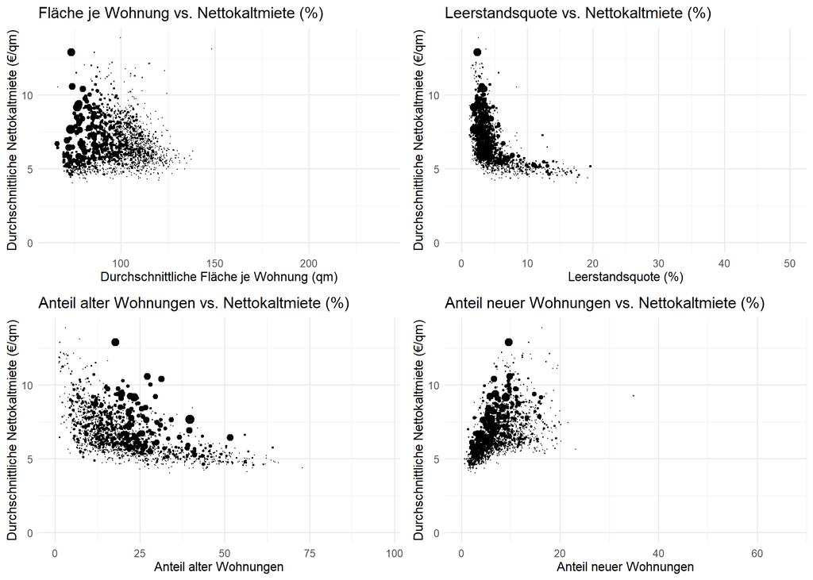

Die Diagramme beschreiben, wie die Variablen “Durchschnittliche Wohnfläche”, “Leerstandquote”, “Anteil alter Wohnungen” und “Anteil neuer Wohnunugen” im Zusammenhang mit den der durchschnittlichen Nettokaltmiete pro Quadratmeter stehen. Dabei stellt jeder Punkt eine Beobachtung in Form einer Gemeinde dar und je mehr Wohnungen diese Gemeinde hat, desto größer erscheinen die Punkte.

Eine Betrachtung des Diagramms, welches den Zusammenhang zwischen der durchschnittlichen Wohnfläche und der durchschnittlichen Nettokaltmiete pro Quadratmeter darstellt, zeigt, dass die Punkte eine hohe räumliche Dichte aufweisen. Es lassen sich preisliche Ausreißer nach oben beobachten, wobei diese bei einer kleineren durchschnittlichen Wohnung eine größere Spannweite aufweisen. Die Größe der Punkte im Diagramm lässt erkennen, dass in Städten mit einer größeren Anzahl an Wohnungen die durchschnittliche Wohnfläche geringer ausfällt als in Gemeinden mit einer geringeren Anzahl an Wohnungen. Zusätzlich lässt sich feststellen, dass Gemeinden mit vielen Wohnungen tendenziell teurer ausfallen, trotz der geringen Größe.

Es lässt sich eine inverse Beziehung zwischen der Leerstandsquote und der Nettokaltmiete beobachten, wobei eine steigende Leerstandsquote mit einer sinkenden Nettokaltmiete einhergeht. Es lässt sich eine Korrelation zwischen hohen Leerstandsquoten und besonders niedrigen Mieten beobachten.

Es lässt sich eine abnehmende Tendenz beobachten: Der Anteil alter Wohnungen korreliert negativ mit der Höhe der Mieten. In Regionen, in denen der Anteil alter Wohnungen mehr als 50 % beträgt, werden Nettokaltmieten von oftmals weniger als 5 €/m² erzielt. Zusätzlich lässt sich erkennen, dass bei gleichem Anteil alter Wohnungen die durchschnittlichen Nettokaltmieten für größere Städte teurer ausfallen.

Wohnfläche: Es lässt sich keine signifikante lineare Korrelation zwischen der durchschnittlichen Fläche und dem Quadratmeterpreis feststellen. Die Datenverteilung präsentiert sich relativ breit und chaotisch, insbesondere im Bereich kleiner Wohnflächen. Dennoch lässt sich eine schwache Tendenz ableiten, dass größere Wohnungen tendenziell einen leicht geringeren Mietpreis pro Quadratmeter aufweisen.

Leerstandsquote:Die Analyse der Leerstandsquote ergibt eine signifikante negative Korrelation. In Regionen mit hoher Leerstandsquote werden tendenziell niedrigere Mietpreise beobachtet. In Gemeinden mit niedrigen Leerstandsquoten hat ein Wohnungssuchender weniger Auswahl denn das Angebot fällt knapper aus. Dies treibt den Preis in diesen Gemeinden nach oben, denn das Angebot bleibt gleich, jedoch ist die Nachfrage größer.

Anteil alter Wohnungen: Der Anteil alter Wohnungen ist ein weiterer Faktor, der einen Einfluss auf die Mietpreise ausübt. Hier ist eine negative Korrelation erkennbar, welche bedeutet, dass in Gemeinden mit einem hohen Anteil an älteren Wohnungen tendenziell niedrigere Mieten zu verzeichnen sind. Dies kann auf eine veraltete Ausstattung oder einen schlechten Zustand der Wohnungen zurückzuführen sein.

Anteil neuer Wohnungen: In diesem Zusammenhang ist eine positive Korrelation erkennbar. In Gebieten mit einem höheren Anteil an Neubauten fallen die Mietpreise oftmals höher aus, da diese Wohnungen moderner und für Mieter attraktiver sind.

Grundsätzlich ist in allen Grafiken zu erkennen, dass die Mieten in größeren Gemeinden teurer sind als in kleineren Gemeinden, obwohl diese oft größere und neuere Wohnungen anbieten. Dies könnte darauf zurückzuführen sein, dass viele Menschen aufgrund der vielfältigen beruflichen Möglichkeiten in Großstädten leben möchten, wodurch die Nachfrage nach einer Wohnung in einer größeren Gemeinde steigt. Da die Nachfrage größer ist als das Angebot, können Vermieter höhere Preise verlangen und Mieter sind gezwungen, diese zu akzeptieren, wenn sie in dieser Stadt leben wollen.

Weiterhin wäre es von Interesse in die einzelnen Großstädte Deutschlands genauer hineinzuschauen, um dort auf Besonderheiten im Wohnmarkt einzugehen. Im ersten Schritt sollen Sie Eigenschaften in Bezug auf die Wohnungen genauer untersucht werden, um zu verstehen, welche Faktoren den Mietpreis innerhalb der urbanen Räume beeinflussen könnten. Anschließend wäre es von Interesse, auch die demografischen Merkmale der Mieterinnen und Mieter in den Blick zu nehmen. Dabei stellt sich die Frage, ob und in welchem Maße diese Einfluss auf die Mietpreise und deren Struktur nehmen.

In der vorherigen Aufgabe wurden Zusammenhänge zwischen dem Alter von Wohnungen und dem Mietpreis auf Gemeindeebene untersucht. Nun soll der Fokus darauf liegen, wie sich die Wohnungen in größeren Städten hinsichtlich ihres Alters verteilen.

8. Erstellen Sie ein Balkendiagramm für alle nachfolgenden Städte: `Stuttgart, Landeshauptstadt`, `Ulm, Universitätsstadt`, `Düsseldorf, Stadt`, `Berlin, Stadt`. Betrachten Sie dabei, wie das Alter der Wohnungen zwischen den Städten variiert. Sie sollen analysieren, wie groß der Anteil der Wohnungen abhängig nach den jeweiligen Baujahrsgruppen in den Städten ist. Tragen Sie in ihrem Balkendiagramm den *Anteil der Wohnungen nach den Baujahren* (auf der y-Achse) gegeben der *Baujahre für jede Stadt* (auf der x-Achse) ab.

Beschreiben und interpretieren Sie die Grafik. Haben Sie diese Unterschiede erwartet? Begründen Sie warum oder warum nicht.

*Hinweis:* Denken Sie daran das Faktorvariablen in ggplot hilfreich sein können.

[figure not shown]

Grundsätzlich lässt sich feststellen, dass die Großstädte den größten Teil ihrer Wohnungen in den Nachkriegsjahren nach dem Ersten und nach dem Zweiten Weltkrieg gebaut haben. Dies ist vermutlich darauf zurückzuführen, dass in den Kriegen durch Bombardierungen und Städte Kämpfe viele Wohnungen beschädigt oder zerstört wurden und wieder aufgebaut werden mussten. Ulm ist davon zwar auch betroffen, aber nicht so stark, da die anderen Städte größer sind und dementsprechend häufiger Ziel von Kriegshandlungen waren. Hinzu kam, dass die Bundesrepublik nach dem Zweiten Weltkrieg eine hohe Geburtenrate und einen wirtschaftlichen Aufschwung erlebte, so dass viele Gastarbeiter nach Deutschland kamen. Für die Gastarbeiter und auch für die Neugeborenen wurde neuer Wohnraum benötigt, was den Wohnungsneubau förderte.

Mit dem Rückgang der Geburtenrate und der Zuwanderung von Gastarbeitern im Laufe der Jahrzehnte sank auch die Nachfrage nach neuen Wohnungen, so dass immer weniger Wohnungen gebaut wurden. Die Grafik zeigt, dass vor allem in den Großstädten Berlin, Stuttgart und Düsseldorf der Wohnungsneubau in diesen Jahrzehnten kontinuierlich zurückgegangen ist.

Ulm stellt hier einen moderaten Ausreißer dar. Die Trends sind zwar wie in den Großstädten erkennbar, aber nicht so stark ausgeprägt. Die Wohnungspolitik in Ulm war über die Jahrzehnte konstanter und ausgeglichener.

9. Wie in der vorherigen Aufgabe zu sehen war, unterscheidet sich die Situation in Städten in Bezug auf die jeweiligen Baujahre der Wohnungen deutlich. Es wäre noch spannend zu sehen, ob auch das Alter der Bewohner, die Familienstände, oder die Einwanderungshistorie der Bewohner mit unterschiedlichen Mietpreisen assoziiert sind. Hier sollen Sie in einem ersten generellen Schritt ein paar demografische Faktoren einbeziehen, inwiefern diese eine Auswirkung haben. Betrachten Sie folgende Eigenschaften genauer:
- Familienstand
- Alter der Bewohner
- Einwanderungsgeschichte

Erstellen Sie eine oder mehrere passende Diagramme oder Grafiken für die in Aufgabe 8 aufgeführten Städte.

Beschreiben und interpretieren Sie diese. Haben Sie diese Unterschiede erwartet? Begründen Sie warum oder warum nicht. Wo gibt es Ihrer Ansicht nach besondere Auffälligkeiten? Warum kann es bei der unterschiedlichen Einteilung der Altersgruppen zu Problemen kommen? Was wären Möglichkeiten, um etwaige Probleme zu vermeiden?

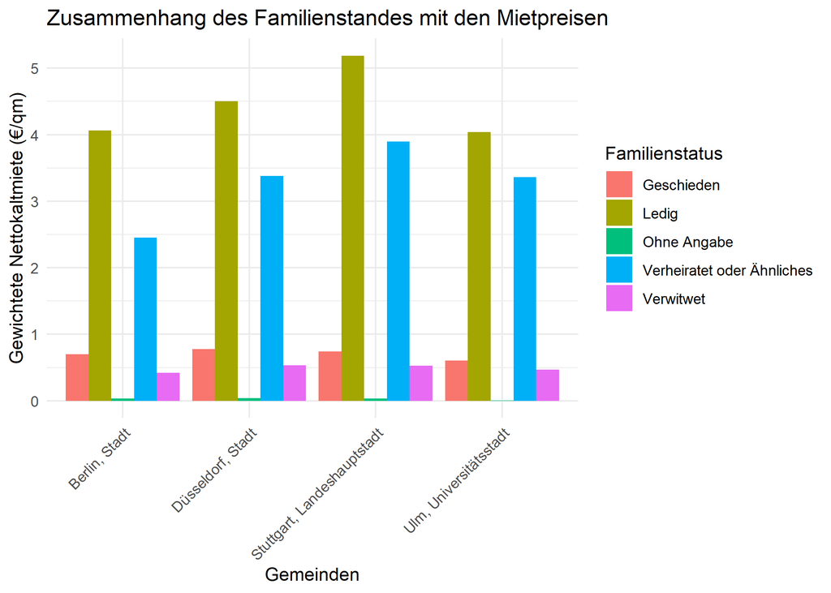

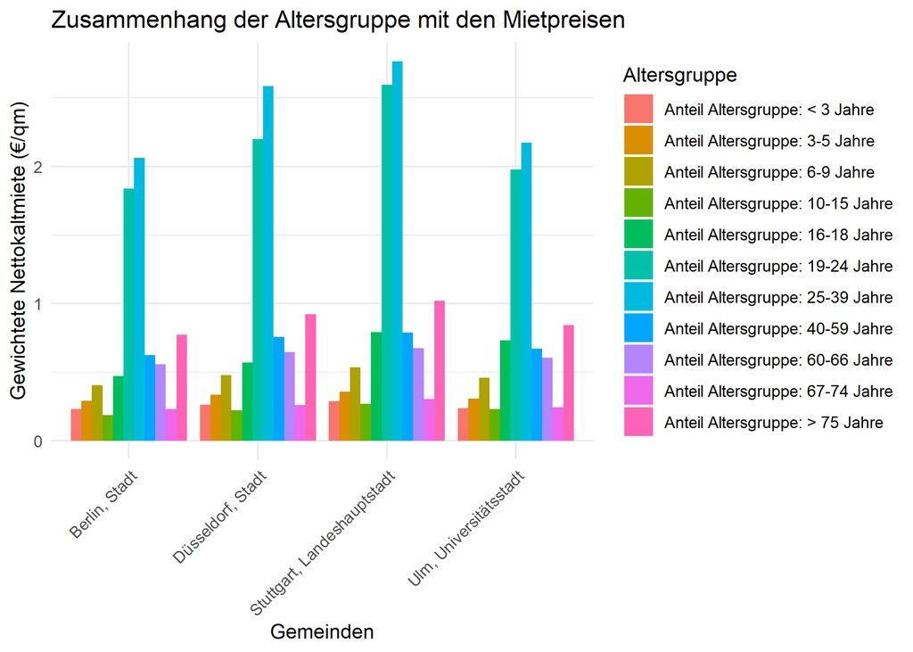

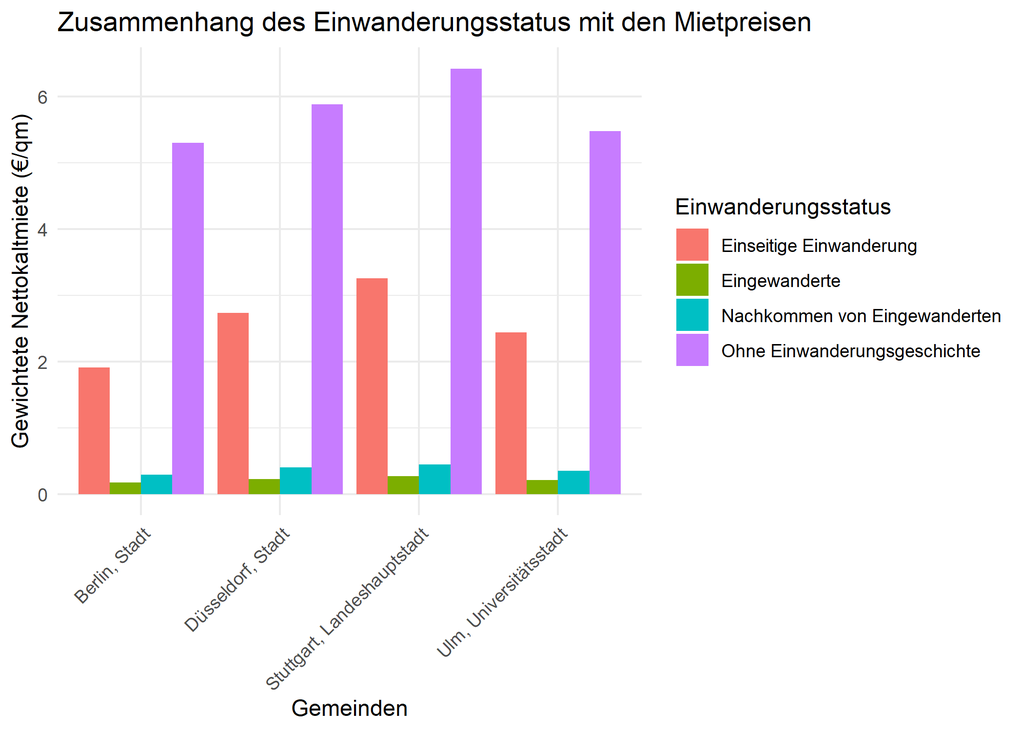

Die Grafik bezüglich des Familienstandes entspricht den Erwartungen. Man erkennt, dass die Nettokaltmiete pro Quadratmeter in allen Städten für die Gruppe der Singles am höchsten ist, besonders hoch mit über 5 Euro/m² in Stuttgart, weniger hoch in Ulm oder Berlin. Die zweithöchsten Mietpreise sind für Ehepaare oder eingetragene Lebensgemeinschaften zu verzeichnen. Auch hier liegt Stuttgart mit knapp 4 Euro/m² an der Spitze und Berlin bildet das deutliche Schlusslicht. Personen, die keine Angaben zum Familienstand gemacht haben, treten in der anteiligen durchschnittlichen Nettokaltmiete pro Quadratmeter kaum in Erscheinung. Die Unterschiede bei den Verwitweten und Geschiedenen sind marginal, interessant ist hier, dass die Miete für diese Gruppen in allen Städten unter einem Euro pro Quadratmeter liegt.

Dass Singles den höchsten Anteil an der Durchschnittsmiete haben, könnte daran liegen, dass sie in der Regel kleinere Wohnungen bewohnen. Diese sind auf den Quadratmeter umgerechnet meist teurer als eine größere Wohnung. Diese größeren Wohnungen werden dann von Ehepaaren oder Paaren mit eingetragener Lebensgemeinschaft bewohnt, die einen geringeren Quadratmeterpreis zahlen. Einen ähnlich geringen Anteil an den durchschnittlichen Mietkosten haben geschiedene oder verwitwete Personen. Sie sind in Bezug auf die Wohnpräferenzen den Ledigen gleichzustellen, allerdings ist diese Personengruppe zahlenmäßig weniger stark vertreten und trägt daher einen geringeren Anteil der Miete.

Betrachtet man die verschiedenen Altersgruppen und ihren Beitrag zur durchschnittlichen Nettokaltmiete pro Quadratmeter, so zeigt sich in allen vier untersuchten Städten, dass vor allem die 25- bis 39-Jährigen die Mietpreise beeinflussen und tragen. Ähnlich verhält es sich mit der Altersgruppe zwischen 19 und 24 Jahren, die einen großen Teil der Mieten verursacht und trägt. Die nächstgrößere Altersgruppe, die den Mietpreis maßgeblich beeinflusst und trägt, ist die der über 75-Jährigen. Darüber hinaus ist festzustellen, dass die Altersgruppen 16-18 Jahre, 40-59 Jahre und 60-66 Jahre einen mäßigen Einfluss auf die Mieten haben. Die übrigen Altersgruppen haben einen geringen Einfluss auf die Mietpreise.

Die Grafik entspricht im Wesentlichen unseren Erwartungen, außer dass die Altersgruppe der 19-24-Jährigen einen so starken Einfluss auf die Mietpreise hat, da wir bei der Altersgruppe der 5-Jährigen einen geringeren Einfluss erwartet hatten. Die gleiche Vermutung gilt für die Altersgruppe 75 Jahre und älter. Hier haben wir aufgrund der niedrigen Renten einen geringeren Einfluss vermutet. Ein Grund dafür, dass die Altersgruppe der 19- bis 24-Jährigen einen so großen Einfluss auf die Mieten hat, könnte sein, dass viele Menschen in diesem Alter studieren und dafür in Städte mit Universitäten ziehen. Dadurch stellen sie einen großen Teil der Bevölkerung dieser Stadt dar und haben somit auch einen großen Einfluss auf die Mietpreise. In der Altersgruppe der 25- bis 39-Jährigen leben viele ausgebildete Fachkräfte, die am Arbeitsort wohnen und somit einen großen Einfluss auf die Mieten haben. Außerdem sind ihre Mietverträge tendenziell jünger, so dass Faktoren wie Inflation, hohe Energiepreise und ein knappes Angebot stärker berücksichtigt werden können. Bei der Altersgruppe 75 Jahre und älter kann es sein, dass viele noch ältere Mietverträge aus der Zeit ihrer Erwerbstätigkeit besitzen, deren Preise nicht an die aktuellen Marktpreise angepasst sind. So können sie sich trotz Rente noch eine Wohnung in der Großstadt leisten.

Die Einteilung in verschiedene Altersgruppen führt zu mehreren Problemen. Zum einen werden Kinder und Jugendliche berücksichtigt, obwohl sie in der Regel bei ihren Eltern wohnen. Sie haben zwar Einfluss auf die Mietpreise, müssen diese aber nicht selbst tragen, sondern meist die Eltern. Ein weiterer Nachteil der Altersgruppen ist, dass die Intervalle der Altersklassen nicht gleich groß sind. So umfassen einige Altersgruppen 19 Jahre, andere dagegen nur 5 Jahre, was zu Verzerrungen führt.

Eine Möglichkeit, dieses Problem zu beheben, besteht darin, gleich große Altersgruppen zu bilden und erst mit 18 Jahren zu beginnen. Auf diese Weise werden die Mietpreise Anteile der Minderjährigen auf die Volljährigen, die in der Regel erwerbstätig sind, umgelegt, um die tatsächliche Belastung unter Berücksichtigung eventueller Kinder widerzuspiegeln.

Die Grafik entspricht den Erwartungen und zeigt, dass die Einwohner ohne Migrationshintergrund in allen Städten den größten Teil der Miete tragen. Ihr Anteil an den Mietkosten beträgt rund zwei Drittel. An zweiter Stelle folgt die Gruppe der Personen mit Migrationshintergrund. Sie tragen zwischen 25 und 30 % des Mietpreises. Zuwanderer und ihre Nachkommen tragen einen kleinen Teil der durchschnittlichen Miete.

Personen ohne Migrationshintergrund könnten einen größeren Einfluss auf die Mietpreise haben, da sie den Großteil der Bevölkerung ausmachen und in einer Familie aufgewachsen sind, die in Deutschland den Grundstein für ihre Zukunft gelegt hat. So haben diese Personen oft einen guten Zugang zu höherer Bildung und können dadurch ein höheres Einkommen erzielen. Dies ermöglicht ihnen den Bezug einer größeren Wohnung. Personen mit einseitigem Migrationshintergrund haben zum Teil die Vorteile von Personen ohne Migrationshintergrund, dass sie einen besseren Zugang zu höherer Bildung haben, aber diese Familien sind in der Gesellschaft weniger etabliert und können nicht die gleichen Chancen schaffen wie Familien ohne Migrationshintergrund. Zuwanderer haben es schwerer, denn auch wenn sie in ihrem Herkunftsland einen Hochschulabschluss oder eine Berufsausbildung erworben haben, wird dieser in Deutschland oft nicht anerkannt und sie arbeiten meist in schlechter bezahlten Berufen. Das wiederum schränkt sie bei der Wohnungswahl ein. Ähnlich verhält es sich bei ihren Nachkommen, die nicht wie die Nachkommen aus Familien ohne Zuwanderungsgeschichte auf ein finanziell starkes Umfeld zurückgreifen können.

In den bisherigen Analysen wurden demografische und wohnungsbezogene Faktoren in verschiedenen Städten Deutschlands untersucht. Dabei lag der Fokus darauf, wie diese Merkmale in unterschiedlichen Regionen das Mietpreisniveau und dessen Struktur beeinflussen. Aufbauend auf diesen Erkenntnissen soll der Blick nun gezielt auf den Vergleich zwischen Ost- und Westdeutschland gelenkt werden. Diese regionale Differenzierung ermöglicht es, potenzielle Unterschiede und Gemeinsamkeiten zwischen den beiden Landesteilen genauer zu analysieren. Insbesondere wird betrachtet, wie sich die Mietpreisstruktur in Ost- und Westdeutschland darstellt und ob sich hierbei spezifische Muster oder Abweichungen erkennen lassen.

10. Betrachten Sie nun die Städte `Dresden, Stadt`, `Chemnitz, Stadt`, `Stuttgart, Landeshauptstadt`, `Ulm, Universitätsstadt`,`Düsseldorf, Stadt`und `Berlin, Stadt`. Vergleichen Sie in einem ersten Schritt die Anzahl an Einwohnern, den Anteil an Menschen, die deutscher Herkunft sind, den Anteil an neuen und alten Wohnungen, sowie die durchschnittlichen Mietpreise. Erweitern Sie ihre Analyse um die durschnittlichen Wohnflächen.

Erstellen Sie für die genannten Städte eine deskriptive Tabelle. Beschreiben und interpretieren Sie diese. Beantworten Sie insbesondere folgende Fragen:

- In wie weit könnte das Alter der Wohnungen eine Rolle für den Mietpreis spielen?
- Gibt es Auffälligkeiten zwischen den einzelnen Städten in Bezug auf Herkunft der Bewohner, Einwohner und Größe der Wohnungen?
- Warum könnte es problematisch sein, wenn Sie die Städte als ein Ganzes betrachten?
- Sind Ihre Ergebnisse auf die ganze Stadt verallgemeinerbar?
- Was sind ihrer Meinung nach Faktoren, die die unterschiedlichen Mietpreise in Ost und West erklären?
- Welche Maßnahmen wären geeignet, um in Düsseldorf, Ulm und Stuttgart die Mietpreisstruktur anzupassen und bezahlbaren Wohnraum zu schaffen?

| Stadt | Einwohner | Anteil Deutscher (%) | Anteil alter Wohnungen (%) | Anteil neuer Wohnungen (%) | Durchschnittliche Nettokaltmiete (€/m²) | Wohnfläche(m²) | Wohnfläche pro Einwohner (m²) |
| --- | --- | --- | --- | --- | --- | --- | --- |
| Düsseldorf, Stadt | 611258 | 77.24 | 22.11 | 5.78 | 9.24 | 77.56 | 44.36 |
| Stuttgart, Landeshauptstadt | 610458 | 74.30 | 31.33 | 6.57 | 10.39 | 79.76 | 41.08 |
| Ulm, Universitätsstadt | 127116 | 78.22 | 19.02 | 9.26 | 8.48 | 87.64 | 44.44 |
| Berlin, Stadt | 3596999 | 80.46 | 39.72 | 5.92 | 7.67 | 73.22 | 41.10 |
| Chemnitz, Stadt | 240078 | 90.23 | 41.03 | 3.18 | 5.26 | 71.33 | 45.12 |
| Dresden, Stadt | 557782 | 90.69 | 39.61 | 6.62 | 6.92 | 71.24 | 40.81 |

11. Lesen Sie den [folgenden Artikel](https://www.tagesschau.de/wirtschaft/sozialwohnungen-bau-mangel-101.html). Dort werden Sozialwohnungen thematisiert, warum so viele fehlen und wer davon vor allem betroffen ist. Beantworten Sie anschließend folgende Fragen:
- Welche Bevölkerungsgruppen sind am stärksten von der Sozialwohnungsnot betroffen und inwiefern?
- Was sind Gründe, warum es zu wenige Sozialwohnungen gibt?
- Wie sieht die historische Entwicklung des Sozialwohnungsbaus aus, im Hinblick auf Vorhandensein von Wohnungen und Investitionen in den Bau von neuen Wohnungen?
- Welche Anreize könnten Investoren motivieren, mehr Sozialwohnungen zu bauen?
- Welche innovativen Ansätze können Bauherren verfolgen, um die Kosten für den Wohnungsbau zu senken?

Gerade die Einkommens Schwächsten, die die Sozialwohnungen am dringendsten benötigen, haben keine mehr, viele Familien, die vor einigen Jahren noch gut situiert waren, sind in finanzielle Not geraten und das immer knapper werdende Angebot auf dem gesamten Wohnungsmarkt lässt die Mieten weiter steigen. Selbst wer einen Wohnberechtigungsschein hat, bekommt oft keine Sozialwohnung, weil es einfach nicht genug gibt. Sie stehen auf Wartelisten. In den 90er Jahren gab es in Deutschland rund drei Millionen Sozialwohnungen, heute sind es nur noch 1,1 Millionen, unter anderem weil die Sozialbindungen auslaufen. 100.000 neue Sozialwohnungen wollte die Regierung bauen, stattdessen ist die Zahl um 27.000 gesunken, und auch in diesem Jahr wird das Ziel der Regierung wohl verfehlt. Die Zahl der Wohnungen, die nach 25 bis 30 Jahren aus der Mietpreisbindung herausfallen, ist höher als die Zahl der geförderten Neubauten, die Zinsen sind stark gestiegen, die Baukosten stark gestiegen, die Krise in der Ukraine verschärft das Problem der Versorgungskette. Bauen, ob gefördert oder nicht, wird immer teurer. Für Investoren gab es bei geförderten Projekten auch bei Mieten um die sechs Euro noch eine Rendite. Diese wird nun von den Kosten aufgefressen. Viele Städte berichten, dass die laufenden Baustellen noch abgearbeitet werden, neue Projekte aber kaum geplant sind. In den 90er Jahren gab es 1,9 Millionen Sozialwohnungen mehr.  
Mit deutlich mehr Förderung würden Investoren wieder Anreize bekommen, mit weniger Auflagen und schnelleren Genehmigungen könnte das Bauen einfacher, schneller und damit billiger werden - und es könnte zügig mehr Bauland erschlossen werden.Günstiger und intelligenter muss gebaut werden, kleinere Treppenhäuser, geringere Wandstärken, hin zum Holzbau, Flachdächer ohne Attika planen, und beim Schallschutz muss Deutschland nicht noch besser werden, weil es schon das Beste ist. Innovationen sind gefragt und die Industrie muss wieder mehr Fantasie entwickeln, um billiger und intelligenter zu bauen.

12. Gerade die Politik ist gefordert, bezahlbaren Wohnraum zu realisieren. Dabei gibt es eine Viezahl an politischen Maßnahmen, die aufgestellt wurden und umfangreich diskutiert werden. Betrachten Sie die folgenden Maßnahmen, welche helfen sollen, die angespannte Lage auf dem Mietmarkt zu entlasten. Argumentieren Sie, warum diese Maßnahmen sinnvoll/nicht sinnvoll sind und in welcher Art und Weise diese umgesetzt werden können.
1. “Fachleute fordern, die Regulierung von Bestandsmieten zu lockern, damit sich ihr Niveau den Neuvertragsmieten annähert, mehr Menschen umziehen und sich Wohnraum besser verteilt.”
2. “Eine weitere Möglichkeit wäre, Mieterhöhungen bei Neuvertragsmieten zu begrenzen.”
3. “Am einfachsten ist es, wenn vor allem in Großstädten, wo bezahlbarer Wohnraum fehlt, mehr gebaut wird.”
4. “Am besten wäre es, wenn zukünftig mehr Vermieter in regelmäßigen Abständen die Miete anpassen.”
1. Wenn sich die Bestandsmieten den Neuvertragsmieten annähern, könnten mehr Menschen bereit sein, umzuziehen. Dies könnte eine effizientere Nutzung von Wohnraum fördern und Leerstände reduzieren.Außerdem könnten höhere Mieten Vermieter dazu motivieren, in die Instandhaltung und Modernisierung von Mietwohnungen zu investieren und so den Wohnstandard zu verbessern.Außerdem könnte eine Anpassung der Bestandsmieten an die Neuvertragsmieten als gerechter angesehen werden, da Mieter, die schon lange in einer Wohnung wohnen, nicht unverhältnismäßig niedrigere Mieten zahlen als neue Mieter. Allerdings könnte eine Erhöhung der Bestandsmieten einkommensschwache Mieter, die schon lange in ihrer Wohnung leben, stark belasten und zu Verdrängung führen. Andererseits fördern günstige Bestandsmieten die langfristige Bindung von Mietern, was zu stabilen Nachbarschaften und weniger Fluktuation führt. Eine Angleichung der Bestandsmieten an die Neuvertragsmieten könnte in Märkten mit bereits hohen Mieten zu weiteren Preissteigerungen führen und das Problem der Wohnungsknappheit verschärfen. Eine schrittweise Anpassung der Bestandsmieten könnte dazu beitragen, negative soziale Auswirkungen abzumildern und den Mietern Zeit zur Anpassung zu geben.Weitere Möglichkeiten sind die Einführung von Sozialprogrammen oder Wohngeld, um einkommensschwache Haushalte zu unterstützen und Verdrängung zu vermeiden, sowie die Förderung von Wohnungsbauprojekten und Modernisierungsprogrammen, um das Angebot an preisgünstigen Wohnungen zu erhöhen und gleichzeitig die Qualität zu verbessern. Auch die Offenlegung der Mietpreisgestaltung und die aktive Kommunikation mit den Mietern, um Verständnis und Akzeptanz für Veränderungen zu fördern, können hilfreich sein.
2. Begrenzte Mieterhöhungen können dazu beitragen, Mieter vor übermäßigen Mietsteigerungen zu schützen, insbesondere in stark nachgefragten städtischen Gebieten, in denen die Mieten oft schnell steigen. Darüber hinaus kann die Mietpreisbremse für mehr finanzielle Stabilität und Planbarkeit für Mieter sorgen, indem sie verhindert, dass neue Mieter plötzlich viel höhere Mieten zahlen müssen als ihre Vorgänger. Die Begrenzung von Mieterhöhungen könnte auch dazu beitragen, die soziale und wirtschaftliche Segregation zu verringern, indem sie es Menschen mit geringerem Einkommen ermöglicht, in zentralen städtischen Gebieten zu wohnen.

Allerdings könnten solche Beschränkungen den freien Markt verzerren und die Investitionsanreize für Vermieter verringern, was langfristig zu einer Verknappung des Wohnungsangebots führen könnte. Außerdem könnten Vermieter, die ihre Mieteinnahmen nicht an die Marktbedingungen anpassen können, weniger in die Instandhaltung und Modernisierung von Wohnungen investieren, was zu einer Verschlechterung der Wohnqualität führen könnte. Vermieter könnten auch versuchen, die Beschränkungen zu umgehen, indem sie die Mieten anderer Wohnungen erhöhen oder zusätzliche Gebühren einführen.

Begrenzungen sollten in Kombination mit anderen wohnungspolitischen Maßnahmen wie der Förderung von Neubauprojekten und der Bereitstellung von Sozialwohnungen umgesetzt werden. Die Einführung der Mietpreisbremse als befristete Maßnahme, die regelmäßig überprüft und gegebenenfalls angepasst wird, wäre eine Möglichkeit der Umsetzung; die Schaffung eines transparenten Systems zur Überprüfung und Durchsetzung der Mietpreisbremse, um Missbrauch zu verhindern, und die Gewährung von Steuervergünstigungen oder anderen Anreizen für Vermieter, die bereit sind, ihre Mieten zu begrenzen und gleichzeitig in die Instandhaltung und Modernisierung ihrer Wohnungen zu investieren, sind weitere Möglichkeiten.

3. Durch den Bau neuer Wohnungen kann das Angebot an Wohnraum erhöht werden, was zu einer Stabilisierung oder sogar Senkung der Preise beiträgt. Insbesondere in Großstädten mit hoher Nachfrage kann zusätzlicher Wohnraum dazu beitragen, die akute Wohnungsnot zu lindern. Der Bau neuer Wohnungen kann auch die Bauwirtschaft ankurbeln und Arbeitsplätze schaffen. Neue Gebäude können zudem energieeffizient und nachhaltig gestaltet werden, was langfristig die Umweltbelastung reduziert. Eine Zunahme von Bauprojekten kann jedoch zu einer stärkeren Verdichtung und zum Verlust von Grünflächen führen, was die Lebensqualität beeinträchtigen kann. Neue, oft teurere Wohnungen können zu einer Gentrifizierung führen, bei der einkommensschwache Bewohner aus ihren Quartieren verdrängt werden. Ein starker Anstieg der Einwohnerzahl kann auch die bestehende Infrastruktur (z.B. Verkehr und Bildung) überlasten, wenn diese nicht entsprechend ausgebaut wird. Der Bau neuer Wohnungen ist teuer und muss finanziert werden, was zu höheren Mieten führen kann, wenn die Investoren ihre Kosten decken wollen. Neue, oft teurere Wohnungen können zu einer Gentrifizierung (Ärmere werden verdrängt) führen, bei der einkommensschwache Bewohner aus ihren Vierteln verdrängt werden. Ein starker Anstieg der Einwohnerzahl kann auch die bestehende Infrastruktur (z.B. Verkehr und Bildung) überlasten, wenn diese nicht entsprechend ausgebaut wird. Der Bau neuer Wohnungen ist zudem teuer und muss finanziert werden, was zu höheren Mieten führen kann, wenn Investoren ihre Kosten decken wollen. Nachhaltige Baustandards und energieeffiziente Gebäude zur Minimierung von Umweltbelastungen, Investitionen in die städtische Infrastruktur parallel zum Wohnungsbau zur Erhaltung der Lebensqualität, ein Teil des Wohnungsneubaus als sozialer Wohnungsbau zur Unterstützung einkommensschwacher Familien und die Einbeziehung der Bevölkerung in die Planungsprozesse zur Berücksichtigung ihrer Bedürfnisse und Wünsche und zur Förderung der Akzeptanz wären wesentliche Umsetzungsvorschläge.
4. Regelmäßige Mietanpassungen tragen dazu bei, die Mieten an die Inflation anzupassen, so dass die Vermieter ihre Einnahmen und die Kaufkraft der Mieteinnahmen stabil halten können. Wenn Mieter wissen, dass Mieterhöhungen regelmäßig und in vorhersehbaren Abständen erfolgen, können sie besser planen und ihr Budget einteilen. Auch die Vermieter können ihre Finanzplanung präziser gestalten. Außerdem kann der Mietmarkt durch regelmäßige Anpassungen dynamischer und flexibler auf wirtschaftliche Veränderungen reagieren. Dies könnte Investitionen in den Wohnungsmarkt fördern und die Qualität der Wohnungen verbessern. Es ist auch möglich, dass sich die Mieten langfristig einander annähern, da die Mieten häufiger angepasst werden und es weniger wahrscheinlich ist, dass langfristige Mietverträge mit niedrigen Kosten langfristig von Vorteil sind.

Häufige Mietanpassungen können jedoch eine finanzielle Belastung für Mieter darstellen, insbesondere für Mieter mit festem oder niedrigem Einkommen. Auch wenn die Erhöhungen vorhersehbar sind, können sie zu Unsicherheit und Stress bei den Mietern führen, insbesondere in Märkten mit hohen Mietsteigerungsraten. Regelmäßige Mietanpassungen können auch dazu führen, dass Mieter mit niedrigem Einkommen aus ihren Wohnungen verdrängt werden, was zu sozialer Ungleichheit und Gentrifizierung beitragen kann. Um dem entgegenzuwirken, könnten Mietanpassungen an einen Index wie den Verbraucherpreisindex gekoppelt werden, um sicherzustellen, dass die Erhöhungen fair und gerecht sind. Jährliche Obergrenzen für Mietanpassungen, um extreme Erhöhungen zu vermeiden und Mieter vor übermäßigen Belastungen zu schützen, wären ein weiterer guter Vorschlag. Mieter könnten auch im Voraus über geplante Mieterhöhungen informiert werden, um ihnen Zeit zur Anpassung zu geben. Am effektivsten wäre es jedoch, Sozialprogramme oder Wohngeld einzuführen, um einkommensschwache Mieter zu unterstützen und sicherzustellen, dass sie trotz regelmäßiger Mietanpassungen in ihren Wohnungen bleiben können.

# Einzelne Stadtteile in Deutschland

In allen vorherigen Aufgaben haben Sie die Städte, Gemeinden oder auch Landkreise immer als ein Ganzes betrachtet. Jedoch ist es schwierig gerade in Großstädten wie Berlin, Düsseldorf oder auch Stuttgart allgemeine Aussagen über die Mietsituation auf Stadtebene zu treffen. Dies liegt unter anderem daran, dass unterschiedliche Stadtviertel unterschiedliche demografische Eigenschaften, sowie eine unterschiedliche Mietstruktur aufweisen können. Hier wäre es sinnvoll sich mit dem Stadtbild und der Verteilung der Mieten genauer auseinanderzusetzen, um zu sehen, wie sich Mieten innerhalb der Stadt verteilen. Wie in Aufgabe 10 zu sehen war, weisen die Städte im Westen Deutschlands untereinander, sowie die Städte im Osten ähnliche Merkmale auf, weshalb Sie sich in den folgenden Aufgaben auf je eine große und eine kleinere Stadt aus beiden Regionen konzentrieren.

13. In dieser Aufgabe sollen Sie ihren Datensatz aus Aufgabe 4, bei dem Sie Kartendaten und Informationen zu Mieten und LEQ auf 1km-Gitterebene heruntergeladen und zusammengefügt haben, verwenden und vier Karten zeichnen, welche die Verteilung der Nettokaltmieten in den Stadtteilen der Städte “Stuttgart, Landeshauptstadt”, “Ulm, Universitätsstadt”, “Chemnitz, Stadt” und “Dresden, Stadt” anschaulich visualisieren.

Erstellen Sie vier Grafiken, beschreiben und interpretieren diese. Gehen Sie insbesondere auf folgende Fragen ein:

- Welche Besonderheiten fallen Ihnen bei diesen Städten auf?
- Gibt es eine Segregation in Bezug auf die Mieten in einzelnen Stadtteilen?
- Falls es eine Segregation gibt, welche Konsequenzen könnte dies haben?
- Welche Rolle spielen geografische oder infrastrukturelle Faktoren bei den Mietpreisen?
- Gibt es Unterschiede zwischen Städten im Osten und Westen Deutschlands, falls ja, welche Einflüsse in Bezug auf Wirtschaft und Arbeitsmarkt könnte dies in den jeweiligen Städten haben?

*Hinweis:* Wenn Sie einheitliche Legenden für die Karten haben möchten und die vier Städte nebeneinander oder untereinander darstellen wollen, so empfiehlt sich das Paket `ggpubr` und dort der Befehl `ggarrange`.

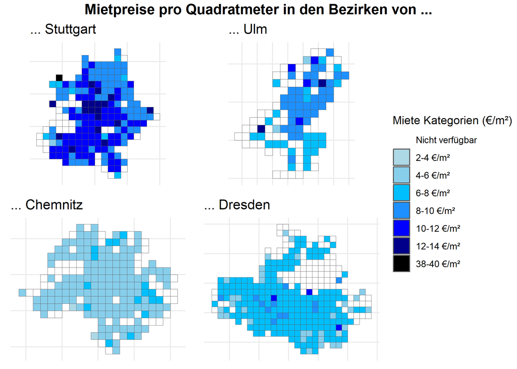

Zunächst fällt auf, dass Stuttgart das Mietpreis Ranking anführt. In Stuttgart ist das Mietpreisniveau relativ homogen, mit einem deutlichen Ausreißer von etwa 38 Euro Durchschnittsmiete pro Quadratmeter in einem nordwestlichen Stadtbezirk. In Ulm ist die Verteilung heterogener. Bezirke mit hohen und niedrigen Durchschnittsmieten liegen dicht beieinander, es gibt wenige Ausreißer unter 6 Euro pro Quadratmeter und wenige Ausreißer über 12 Euro pro Quadratmeter. Wie auch in Stuttgart befinden sich diese Ausreißer eher am Stadtrand. In Chemnitz sind die durchschnittlichen Mietpreise am niedrigsten, sowohl die Ausreißer nach oben ( 6 - 8 Euro pro Quadratmeter) als auch nach unten (4 Euro pro Quadratmeter) liegen tendenziell am östlichen Stadtrand. In Dresden, einer weiteren ostdeutschen Stadt, lässt sich etwas Ähnliches beobachten. Hier ist die Mietpreis Verteilung größtenteils homogen, mit wenigen Ausreißern nach oben in der Stadtmitte und wenigen Ausreißern nach unten am Stadtrand. Die meisten Bezirke haben Mietpreise von etwa 6-8 Euro pro Quadratmeter.

14. Nachdem Sie in Aufgabe 13 die Verteilung der Mieten der einzelnen Stadtteile visualisiert haben, sollten Sie in dieser Aufgabe den Anteil der Leerstandsquoten in den Stadtteilen der Städte “Stuttgart, Landeshauptstadt”, “Ulm, Universitätsstadt”, “Chemnitz, Stadt” und “Dresden, Stadt” veranschaulichen.

Erstellen Sie vier Grafiken, beschreiben und interpretieren diese. Gehen Sie insbesondere auf folgende Fragen ein:

- Was könnten Gründe sein, dass die Leerstandsquote in bestimmten Stadtteilen höher ist, als in anderen?
- Welche Besonderheiten fallen Ihnen bei diesen Städten auf? Auch im Hinblick auf ihre Erkenntnisse aus Aufgabe 13.
- Vergleichen Sie die Grafiken aus Aufgabe 13 und Aufgabe 14. Was könnte der Grund für die unterschiedlichen Muster sein?
- Welche Maßnahmen ergreifen Städte mit hohen Leerstandsquoten, um diese zu reduzieren?

*Hinweis:* Wenn Sie einheitliche Legenden für die Karten haben möchten und die vier Städte nebeneinander oder untereinander darstellen möchten, so empfiehlt sich das Paket `ggpubr` und dort der Befehl `ggarrange`.

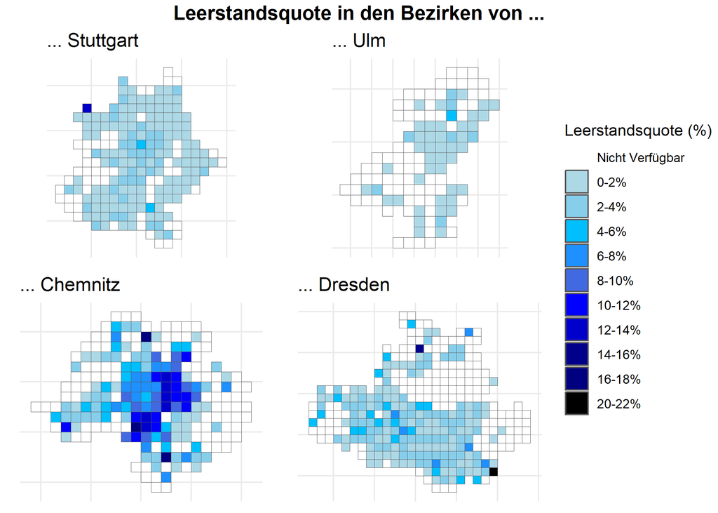

15. Die aktuellen Mietpreise und deren Entwicklungen hindern in Deutschland immer mehr Menschen daran, dass sie sich eine neue geeignete Wohnung suchen. Personen, die aufgrund ihrer aktuellen Lebenssituation sich nach einer neuen Wohnung umsehen, finden oft keine oder können sich diese nicht leisten. Doch worin liegen die Ursachen und Probleme?

Beantworten Sie hierzu folgende Fragen:

- Was versteht man unter dem Lock-in-Effekt, speziell in Bezug auf den Mietmarkt? Wer ist davon vor allem betroffen und warum?
- Gibt es aktuell Möglichkeiten, die vor allem diese “betroffenen” Personen haben, um an bezahlbaren Wohnraum zu gelangen?
- Worin liegen die Ursachen, dass Bestandsmieten (Mieten aus bestehenden Verträgen) und Angebotsmieten (Mieten aus Neuverträgen) so stark voneinander abweichen?

Gehen Sie in ihrer Argumentation auch auf die Grafiken und Ergebnisse der Aufgaben 11, 13 und 14 ein.

Der Lock-in-Effekt bezieht sich auf die Situation, in der Mieter aufgrund der hohen Kosten für neue Mietverträge in ihren bestehenden Mietverhältnissen verbleiben. Dies führt zu einer geringeren Mobilität auf dem Wohnungsmarkt und zu einer ineffizienten Nutzung des Wohnraums, was auch zu einer geringeren Rendite führen kann, wie in Aufgabe 11 erläutert. Besonders betroffen sind einkommensschwache Haushalte, Familien und junge Menschen, die mehr Platz benötigen, wie auch im Beitrag der Tagesschau erwähnt. Diese Gruppen bleiben oft in ihren zu kleinen Wohnungen, weil sie sich keine größere Wohnung leisten können. Um bezahlbaren Wohnraum zu erhalten, gibt es verschiedene Möglichkeiten:

Die Mietpreisbremse stellt ein Instrument der gesetzlichen Regulierung des Mietmarktes dar, welches dazu dient, die Mietpreisentwicklung bei Neuvermietungen zu dämpfen. Die gesetzliche Regelung besagt, dass die Miete bei neuen Vertragsabschlüssen höchstens 10 % über der ortsüblichen Vergleichsmiete liegen darf. Diese Maßnahme zielt darauf ab, eine überproportionale Steigerung der Mieten bei neuen Vertragsabschlüssen in angespannten Wohnungsmärkten zu verhindern. Allerdings bestehen einige Ausnahmen: Ausgenommen von der Mietpreisbremse sind Neubauten, die nach dem 1. Oktober 2014 erstmals genutzt und vermietet wurden, sowie umfassend modernisierte Wohnungen.

In Bezug auf die gesetzlichen Einschränkungen bei Bestandsmieten ist festzuhalten, dass Mietsteigerungen in bestehenden Verträgen in der Regel gesetzlichen Obergrenzen unterliegen. Als üblicher Höchstsatz innerhalb eines Zeitraums von drei Jahren ist eine Begrenzung auf maximal 20 % festgesetzt . In der Konsequenz liegen die Bestandsmieten häufig unterhalb des aktuellen Marktniveaus. Die Marktdynamik bei Neuvermietungen ist durch folgende Faktoren gekennzeichnet. Bei der Gestaltung neuer Mietverträge findet die Nachfrage in Ballungsräumen, in denen das Angebot an Wohnraum knapp ist, in stärkerem Maße Berücksichtigung. In der Konsequenz ist ein Anstieg der Angebotsmieten zu verzeichnen.

Wohngeld stellt eine staatliche Transferleistung dar, welche darauf abzielt, Haushalte mit niedrigem Einkommen zu unterstützen. Es handelt sich um einen staatlichen Zuschuss zu den Wohnkosten, welcher dazu dient, die finanziellen Belastungen für Haushalte mit niedrigem Einkommen zu reduzieren und somit die allgemeine Bezahlbarkeit des Wohnens sicherzustellen. Anspruch auf Wohngeld haben Mieter, deren Einkommen bestimmte Grenzen nicht überschreitet und deren Miete als angemessen gilt. Die Höhe des Wohngeldes ist von verschiedenen Faktoren abhängig, darunter die Einkommenssituation, die Anzahl der Haushaltsmitglieder sowie die Höhe der Miete. Es sei darauf verwiesen, dass es sich bei Wohngeld um eine bedarfsorientierte Unterstützung handelt, welche unabhängig von Regelungen wie der Mietpreisbremse gewährt wird.

# Stadt vs. Land

Bisher haben Sie sich intensiv mit der Wohnsituation in Deutschland auseinandergesetzt und dabei insbesondere die Unterschiede zwischen Ost- und Westdeutschland betrachtet. Im Fokus standen dabei die Mietpreisentwicklung und die Rolle verschiedener Faktoren wie demografische Merkmale, Leerstandsquote, Eigentümerquote, sowie die Wohnfläche. Diese Analysen haben wertvolle Erkenntnisse über die regionale Dynamik des Mietmarkts geliefert.

Nun sollen Sie ihren Blickwinkel erweitern und den Fokus auf eine weitere Ebene der Analyse richten. Im Kern sollen Sie den Unterschied zwischen städtischen Regionen, insbesondere Großstädten, und ländlichen Gebieten untersuchen. Hierbei soll die Mietstruktur in diesen beiden Raumtypen analysiert werden, ob sich die Strukturen von Stadt und Land voneinander unterscheiden.

16. Betrachten Sie in einem ersten Schritt die Wohnungen abhängig ihres Alters. Erstellen Sie dazu eine passende Grafik, die die Verteilung der Wohnungen nach Altersgruppen für die Stadt `Stuttgart, Landeshauptstadt` (Landkreis: Stuttgart, Stadtkreis) im Vergleich zum `Alb-Donau-Kreis` und `Ostalbkreis` darlegt.

Beschreiben und interpretieren Sie ihre Grafik. Woran könnte es liegen, dass es in Stuttgart (in der Stadt) deutlich mehr Altbauwohnungen als auf dem Land gibt? Könnten politische Maßnahmen ihrer Ansicht nach helfen, dass auch in Großstädten mehr neue Wohnungen erbaut und zur Vermietung zur Verfügung gestellt werden?

*Hinweis 1:* Nutzen Sie für die Visualisierung einen Mosaik- oder ein “stacked” Balkendiagramm. Eine Idee, wie Sie das Ganze darstellen können, finden Sie [hier](https://r-graph-gallery.com/).

*Hinweis 2:* Für Stuttgart soll der komplette Landkreis (“Stadtkreis”) untersucht werden.

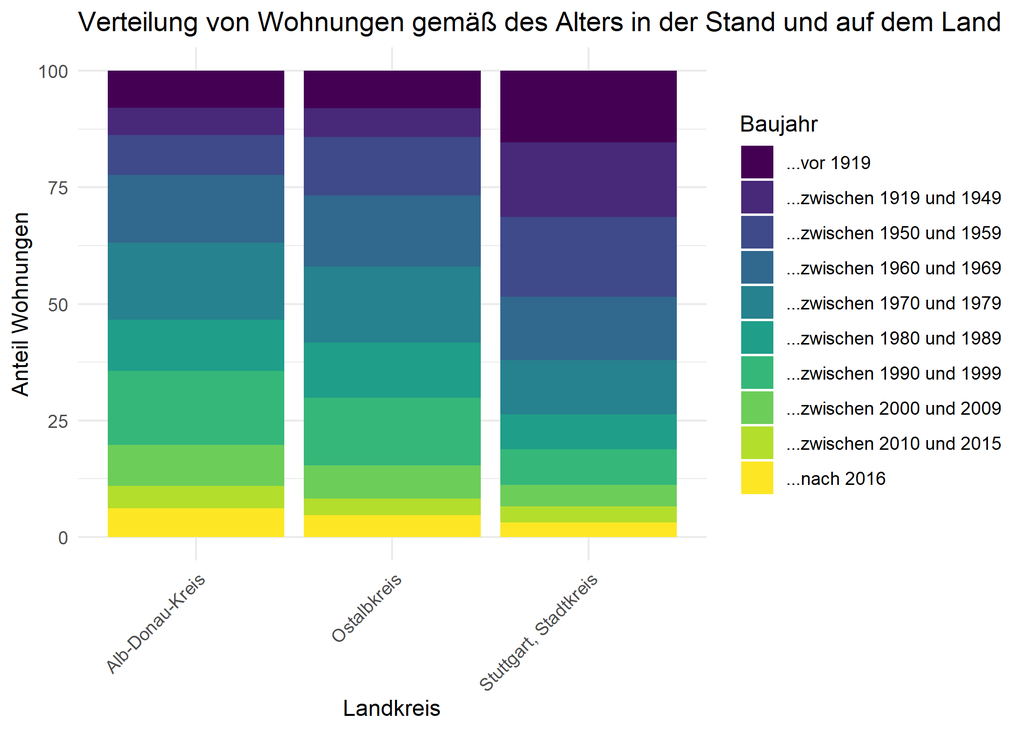

Betrachtet man die Verteilung der Wohnungen in den Landkreisen Alb-Donau-Kreis und Ostalbkreis, so fallen marginale Unterschiede auf. So ist zu erkennen, dass im Alb-Donau-Kreis etwas neuere Wohnungen vorhanden sind, während der Ostalbkreis dies mit Wohnungen aus den Baujahren 1950 bis 1959 ausgleicht. Vergleicht man die beiden Landkreise jedoch mit Stuttgart, so fällt sofort auf, dass beide Landkreise über neuere Wohnungen verfügen und nicht so stark von Altbauten geprägt sind wie Stuttgart.

Politische Maßnahmen könnten dazu beitragen, dass in Großstädten mehr neue Wohnungen gebaut und zur Vermietung angeboten werden. Dazu könnte die Politik verschiedene Anreize oder Förderprogramme einführen, z.B. in Form von Zuschüssen, Steuervergünstigungen oder günstigen Krediten für Bauträger, die nachhaltige und effiziente Projekte in städtischen Gebieten realisieren. Frühere Analysen haben gezeigt, dass der Wohnungsneubau oft an der komplexen Bürokratie scheitert. Eine Möglichkeit, den Wohnungsbau zu fördern, wäre der Abbau von Bürokratie und die Anpassung von Bauvorschriften, um Bauprozesse zu beschleunigen. Dazu gehören die Vereinfachung von Genehmigungsverfahren und der Abbau bürokratischer Hürden. Auch die Aufstockung bestehender Gebäude könnte dazu beitragen, räumliche Engpässe in dicht bebauten Gebieten zu reduzieren.

Solche Maßnahmen könnten dazu beitragen, den Wohnraumbedarf in Städten wie Stuttgart zu decken und gleichzeitig den charakteristischen Charme und das historische Erbe der Stadt zu erhalten. Dabei ist darauf zu achten, dass Neubauten nicht zur Gentrifizierung führen, sondern bezahlbaren Wohnraum sichern.

In einem weiteren Schritt sollen Sie nun die Mietpreise und deren Verteilung analysieren. Hierbei sollen Sie neben der Leerstands- und Eigentümerquote auch auf die Verteilung der Wohnungen nach deren Wohnfläche achten und diese untersuchen.

17 (a). Erstellen Sie zuerst eine Tabelle, die die durchschnittlichen Mietpreise mit der Leerstands- und Eigentümerquote darstellt. Was fällt ihnen dabei besonders auf? Beschreiben und interpretieren Sie ihre Tabelle.

17 (b). Erstellen Sie eine weitere Grafik, die die Verteilung der Wohnungen nach den einzelnen Wohnungsgrößen(<40m² bis >=200m²) abbildet. Stellen Sie darüber hinaus den durchschnittlichen Mietpreis je Landkreis in einer weiteren Grafik dar. Beschreiben und interpretieren Sie ihre Grafiken. Gehen Sie insbesondere auf die Frage ein, ob es Sinn macht sich vor allem den Ostalbkreis oder Alb-Donau-Kreis als ein Ganzes anzusehen und inwieweit überhaupt ein Vergleich zwischen Stadt und ländlicher Region möglich ist.

*Hinweis:* Hier sollen Sie erneut auf dieselben Städte und Landkreise aus Aufgabe 16 eingehen!

| Landkreis | Durchschnittliche Nettokaltmiete (€/m²) | Leerstandsquote (%) | Eigentümerquote (%) |
| --- | --- | --- | --- |
| Alb-Donau-Kreis | 7.00 | 4.82 | 64.16 |
| Ostalbkreis | 6.84 | 4.81 | 60.99 |
| Stuttgart, Stadtkreis | 10.39 | 3.46 | 31.15 |

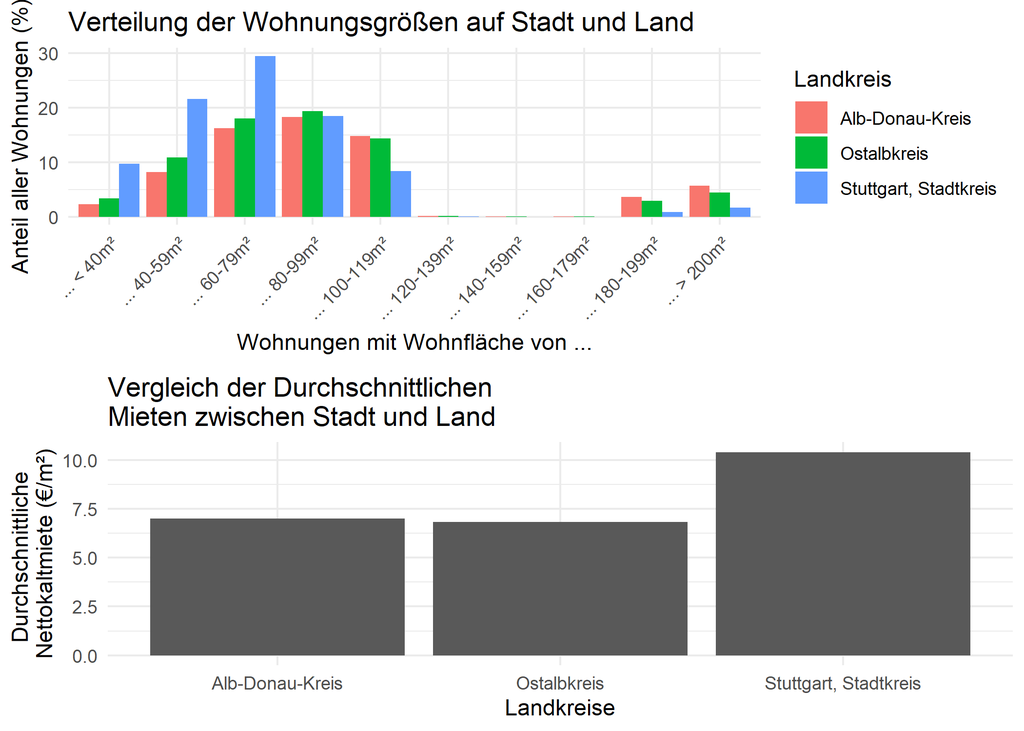

Die Tabelle vergleicht die Variablen durchschnittliche Nettokaltmiete (€/m²), Leerstandsquote (%) und Eigentümerquote (%) für die Landkreise Stuttgart, Stadtkreis, Alb-Donau-Kreis und Ostalbkreis. Bei der durchschnittlichen Nettokaltmiete fällt auf, dass diese für die Landkreise Alb-Donau-Kreis und Ostalbkreis um ca. 30% niedriger ist als für den Stadtkreis Stuttgart. Dagegen ist die Leerstandsquote in den ländlichen Kreisen um rund 38% höher als im Landkreis Stuttgart. Auch die Eigentümerquote ist in den ländlichen Kreisen etwa doppelt so hoch wie in Stuttgart.

Diese Beobachtungen lassen sich damit begründen, dass Stuttgart aufgrund seines Images und der beruflichen Möglichkeiten ein attraktiverer Landkreis ist. Dies führt zu einer höheren Nachfrage nach Wohnraum in Stuttgart und damit zu höheren Mieten. Diese höhere Nachfrage führt trotz der höheren Preise auch zu einer geringeren Leerstandsquote in diesem Landkreis. Allerdings schlagen sich die höheren Mieten auch in der Wohneigentumsquote nieder. Aufgrund der höheren Mieten ist Wohneigentum in Stuttgart ein attraktives Anlagegut, weshalb die Preise für Wohneigentum höher sind als in den ländlichen Kreisen. Dies führt dazu, dass sich weniger Einwohner Wohneigentum leisten können.

Es zeigt sich, dass in Stuttgart die Wohnungen mit einer Wohnfläche unter 40 m² einen höheren Anteil von rund 10 % ausmachen, während dieser Anteil in den ländlichen Kreisen Alb-Donau-Kreis und Ostalbkreis deutlich geringer ist. Grundsätzlich lässt sich feststellen, dass kleine Wohnungen im Stadtkreis Stuttgart einen höheren Anteil an allen Wohnungen ausmachen, während in den Landkreisen eine größere Streuung der Wohnfläche zu beobachten ist. Dies lässt sich daran erkennen, dass Wohnungen mit einer Wohnfläche von weniger als 80 m² in Stuttgart prozentual häufiger sind. Der Anteil größerer Wohnungen sinkt dann aber drastisch und sofort unter den Anteil gleich großer Wohnungen in den ländlichen Kreisen. Insbesondere fällt auf, dass Wohnungen mit einer Wohnfläche von über 180 Quadratmetern und mehr in einem Stadtkreis wie Stuttgart prozentual weniger vertreten sind als gleich große Wohnungen in ländlichen Kreisen. Eine Besonderheit zeigt sich bei Wohnungen mit einer Wohnfläche von 120 bis 179 Quadratmetern. Diese sind in allen drei Landkreisen minimal vertreten. Beim Vergleich des Alb-Donau-Kreises mit dem Ostalbkreis sind marginale Unterschiede in der Verteilung der Wohnungen und deren Wohnfläche festzustellen. Diese liegen in der Regel unter 5 Prozentpunkten und es zeigt sich eine leichte Tendenz, dass im Alb-Donau-Kreis etwas größere Wohnungen vorhanden sind.

Die Tendenz, dass es in ländlichen Gebieten eher größere Wohnungen gibt als in städtischen Kreisen, kann damit erklärt werden, dass in Kreisen wie Stuttgart die Mieten höher sind und weniger Fläche zur Verfügung steht, auf der eine größere Wohnung gebaut werden könnte. Zudem sind die Grundstückspreise in Stuttgart deutlich höher, so dass es schwierig ist, größere Wohnungen zu bauen und Käufer zu finden.

Vergleicht man die Durchschnittsmieten zwischen ländlichen und städtischen Kreisen, so fällt wiederum auf, dass die Mieten in den ländlichen Kreisen um ca. 30% niedriger sind als im städtischen Kreis Stuttgart. Dies ist auf die Attraktivität des Stadtkreises Stuttgart zurückzuführen. Dieser bietet hervorragende berufliche Perspektiven und genießt ein hohes Image. Für diese Vorteile sind die Menschen bereit, höhere Mieten zu zahlen.

Für diesen Vergleich ist es nicht sinnvoll, die Landkreise Ostalbkreis und Alb-Donau-Kreis als Ganzes zu betrachten und mit Stuttgart zu vergleichen. Diese ländlichen Landkreise haben alle eine Kreisstadt, die größer und städtischer geprägt ist. Dies verzerrt die Werte der ländlich geprägten Landkreise, während Landkreise wie Stuttgart eine homogene Struktur aufweisen. Für einen Vergleich zweier ländlicher Kreise ist eine Kreisstadt kein so großes Hindernis, da die Daten beider Kreise in ähnlicher Weise verzerrt werden und somit besser vergleichbar sind.

# Zusatzfrage (optional)

Diese Frage ist von der Bearbeitung her etwas schwieriger. Bevor Sie sich an diese Aufgabe machen, sollten Sie sicherstellen, dass Sie alle vorherigen Fragen ausführlich beantwortet haben. Eine korrekte Beantwortung dieser Frage gibt einen Punktebonus von 3 Punkten (das Projekt umfasst insgesamt 30 Punkte, inkl. Screencast).

Nachdem Sie sich in den bisherigen Aufgaben ausführlich mit den allgemeinen Einflussfaktoren auf die Mietpreise befasst haben, rückt nun ein spezifischer Aspekt in den Fokus: die Rolle der Heizungen. Insbesondere werden Sie untersuchen, wie unterschiedliche Heizungsarten und -systeme die Mietpreise beeinflussen können. Diese Betrachtung ermöglicht es ihnen, die bisherigen Analysen zu verfeinern und den Zusammenhang zwischen energetischen Standards und der Entwicklung von Mietkosten genauer zu erfassen. Aufgabe 18 führt Sie somit zu einem weiteren zentralen Detail der Mietpreisentwicklung, das insbesondere vor dem Hintergrund steigender Energiepreise und der Relevanz nachhaltiger Wohnformen an Bedeutung gewinnt.

18. Lesen Sie den Datensatz `Heiztypen_Zensus.csv` ein und speichern diesen als `heiztypen` ab. Neben den Ihnen bekannten Variablen, finden Sie dort 6 weitere Variablen, die Auskunft über die Heizarten der jeweiligen Wohnung geben. Diese werden wie folgt beschrieben:
- HEIZTYP__1: Gebäude mit Heizungsart Fernheizung (Fernwärme) (Anzahl)
- HEIZTYP__2: Gebäude mit Heizungsart Etagenheizung (Anzahl)
- HEIZTYP__3: Gebäude mit Heizungsart Blockheizung (Anzahl)
- HEIZTYP__4: Gebäude mit Heizungsart Zentralheizung (Anzahl)
- HEIZTYP__5: Gebäude mit Heizungsart Einzel- oder Mehrraumöfen (auch Nachtspeicherheizung) (Anzahl)
- HEIZTYP__6: Gebäude mit Heizungsart Keine Heizung im Gebäude oder in den Wohnungen (Anzahl)

Erstellen Sie eine neue Spalte `heiztypen_gesamt`, welche die Summe über alle Heiztypen hinweg bildet. Bestimmen Sie weiterhin den Anteil der jeweiligen Heiztypen je Gemeinde (als Anteil aller Heizarten). Nun sollen Sie eine oder mehrere passende Grafik(en) erzeugen, die je nach durchschnittlicher Größe der Wohnungen die Anteile der verschiedenen Heizungsarten abbilden. Erstellen Sie weiterhin eine oder mehrere passende Grafik(en) die den Zusammenhang zwischen den Heizungsarten und den durschnittlichen Mietpreisen darstellt. Wiederum soll der Anteil der verschiedenen Heizungsarten abhängig der Mietpreise abgebildet werden.

Beschreiben und interpretieren Sie ihre Schaubilder und gehen Sie insbesondere auf folgende Frage ein:

- Gibt es einen Zusammenhang zwischen der Heizungsart und der Größe der Wohnungen?
- Gibt es einen Zusammenhang zwischen der Heizungsart und den Mietpreisen?
- Was könnten Gründe sein, warum in bestimmten Wohnungsgrößen eher bestimmte Heizungstypen eingebaut werden und andere nicht?
- Warum könnte es sein, dass bei manchen Heizungsarten die Mietpreise höher sind als bei anderen?
- Was könnte die Bundesregierung machen, um trotz neuer und moderner Heizungssysteme die Mietpreise nach oben hin zu beschränken?

*Hinweis 1:* Überlegen Sie sich, ob es ihrer Ansicht nach Sinn macht, die jeweiligen Wohnungsgrößen und durchschnittlichen Mietpreise in Segmente zu unterteilen.

*Hinweis 2:* Eine Möglichkeit die Beziehung zwischen Heizungsarten und Wohnungsgrößen bzw. Heizungsarten und Mietpreisen zu visualisieren wäre beispielsweise ein “stacked” oder “grouped” Balkendiagramm. Überlegen Sie sich, warum diese Form der Darstellung besonders gut geeignet wäre.

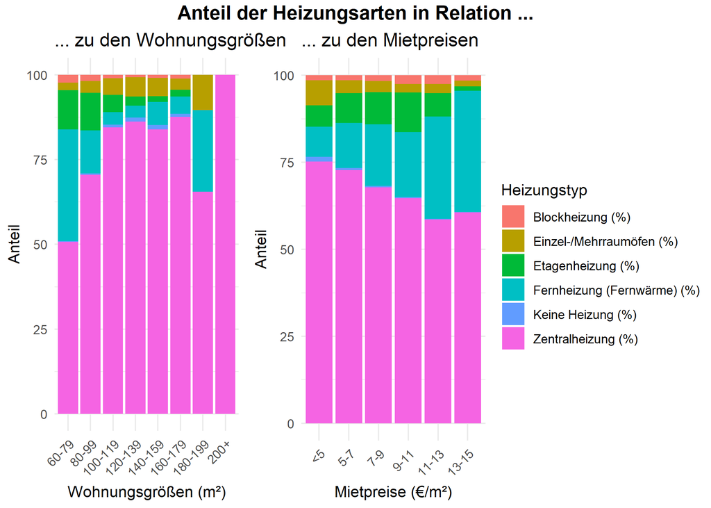

Betrachtet man die verschiedenen Heizungsarten und ihre Verteilung in Abhängigkeit von der Miethöhe, so fällt auf, dass auch hier die Zentralheizung unabhängig von der Miethöhe den größten Anteil der Wohnungen beheizt. Der Anteil der Zentralheizungen nimmt mit steigender Miethöhe ab. Der Trend bei Fernwärmeheizungen ist umgekehrt. Ihr Anteil nimmt mit steigendem Mietpreis zu. Blockheizkraftwerke sind nahezu gleich verteilt und beheizen einen geringen Anteil aller Wohnungen. Mit Etagenheizungen werden vor allem Wohnungen zwischen 5 und 13 Euro beheizt. Es gibt auch einige wenige Wohnungen ohne Heizung.

Zentralheizungen werden vor allem in größeren Wohnungen und Wohnungen mit niedrigen Mieten eingesetzt, da sie ein ganzes Gebäude versorgen. Zentralheizungen mit modernen, umweltfreundlichen Technologien wie Wärmepumpen und Solarthermie reduzieren den Energieverbrauch und die CO2-Emissionen. Zudem ermöglichen sie eine zentrale Temperaturregelung. Die Bewohner müssen die Heizung nicht in jedem Raum einzeln einstellen. Eine Zentralheizung spart Platz, da sie kompakter ist als ein Heizgerät. In großen Wohnungen sind andere Lösungen schwieriger umzusetzen. Die Installation einer Zentralheizung ist in großen Wohnungen oder Häusern wirtschaftlicher, da nur ein Heizkessel benötigt wird. Auch Wartung und Reparaturen sind einfacher. Allerdings nimmt ihr Anteil mit steigenden Mieten ab, da sie den Mietern wenig Flexibilität bieten. Die Vermieter verlangen niedrigere Mieten, um die Flexibilität auszugleichen. Fernwärme wird vor allem in kleineren Wohnungen genutzt. Kleine Wohnungen gibt es eher in großen Städten mit ausgebauter Fernwärme-Infrastruktur. In ländlichen Gebieten fehlt diese, sodass auf andere Heizungsarten zurückgegriffen werden muss. Die Mieten für Wohnungen mit Fernwärme sind höher, was darauf zurückzuführen ist, dass Wohnungen, die an die Fernwärme-Infrastruktur angeschlossen sind, sich in Großstädten befinden. Dies sorgt automatisch für höhere Mietpreise. Zusätzlich gibt es bei der Fernwärme eine geringe Anzahl an Anbietern, weswegen die Preise teurer ausfallen. Etagenheizungen mit eigener Wohnungheizung sind vor allem in Wohnungen mit Mieten zwischen 5 und 13 Euro pro Quadratmeter zu finden. Dies deutet darauf hin, dass Etagenheizungen eher in älteren Gebäuden und in preiswerteren Wohnsegmenten anzutreffen sind.

Eine Möglichkeit, die Mietpreise trotz neuer Heizsysteme zu begrenzen, wäre zum einen die Subventionierung des Einbaus dieser Systeme. Dies würde den Anreiz für Vermieter erhöhen, solche Anlagen zu installieren, und durch die Subventionierung müssten die Vermieter weniger ihrer Investitionskosten in Form höherer Mieten an die Mieter weitergeben. Durch energieeffiziente Systeme könnten auch die Nebenkosten für die Mieter sinken und diese somit weiter entlastet werden.

Eine weitere Möglichkeit ist die Einführung einer Mietpreisbremse, die auch für Neubauten gilt. Neubauten fallen derzeit nicht in den Anwendungsbereich der Mietpreisbremse und durch eine Gesetzesänderung könnten die Mietpreise für Neubauten mit modernen Heizungsanlagen begrenzt werden.

Die Sensibilisierung von Vermietern und Mietern für die Vorteile moderner, energieeffizienter Heizsysteme kann dazu beitragen, Akzeptanz und Nutzung solcher Systeme zu fördern. Informationskampagnen können dazu beitragen, das Bewusstsein für die langfristigen Vorteile zu schärfen

Eine weitere Möglichkeit wäre die Verschärfung der Modernisierungsumlage. Hier hätte die Bundesregierung verschiedene Möglichkeiten, wie z.B. die Anpassung des Prozentsatzes, der dauerhaft aufgeschlagen werden darf. Eine weitere Möglichkeit wäre eine absolute Deckelung der maximalen Mieterhöhung auf z.B. 1 €/m² oder die Regierung könnte die Modernisierungsumlage zeitlich befristen. Dies bietet dem Vermieter die Möglichkeit, seine Investition zu refinanzieren, allerdings nur für einen begrenzten Zeitraum.

Auch gesetzliche Regelungen könnten Abhilfe schaffen, in Deutschland gibt es bereits Regelungen, die die Mieterhöhung nach Modernisierungen begrenzen. Zum Beispiel darf der Vermieter die Miete um maximal 8 % der aufgewendeten Kosten erhöhen, jedoch gedeckelt auf 3 Euro pro Quadratmeter innerhalb von sechs Jahren, wenn die zuvor festgelegte Miete mehr als 7 Euro pro Quadratmeter betragen hat. In allen anderen Fällen ist die Höchstgrenze auf 2 Euro pro Quadratmeter innerhalb von sechs Jahren festgelegt.

Ab dem 1. Januar 2024 tritt das neue Gebäudeenergiegesetz in Kraft, das unter anderem besondere Regeln für die Modernisierung von Heizsystemen enthält. Es legt fest, dass Mieterhöhungen nur unter bestimmten Bedingungen zulässig sind, insbesondere wenn die neuen Heizsysteme mindestens 65 % erneuerbare Energien nutzen.

Wie Sie in der Aufgabe 15 gesehen haben, haben Ulm und Stuttgart, sowie Dresden und Chemnitz ähnliche Verhältnisse bezüglich der Verteilung der Mietkosten über die Stadt hinweg. Aufgrund dessen beschränken Sie sich bei dieser Aufgabe auf die Städte Stuttgart und Dresden. Hier sollen Sie sich die einzelnen Heizungsarten über die Stadtteile hinweg anschauen, wie sich diese verteilen und ob hier Ähnlichkeiten zur Mietpreissstrukur vorliegt. Weiterhin sind vor allem die Heizungsarten Fernwärme, Zentralheizung und Etagenheizung in viele deutschen Wohnungen größtenteils verbaut, weshalb Sie gerade deswegen diese drei Heiztypen genauer beleuchten und untersuchen sollen.

19. Deshalb sollten Sie sich in einem ersten Schritt [diese Geogitter-Daten für die verschiedenen Heinzungsarten vom statistischen Bundesamt herunterladen](https://www.zensus2022.de/static/Zensus_Veroeffentlichung/Zensus2022_Heizungsart.zip). Speichern Sie die zip-Datei im Ordner `Daten` ab. Nutzen Sie erneut den Datensatz shape_file aus der Aufgabe 4 und joinen Sie die Informationen zu den Heizungsarten über die Variablen `x_mp_1km` und `y_mp_1km`.

In ihrem Datensatz können Sie sehen, dass es Einträge mit “-” gibt. Diese sollen sie für alle Heizungstypen durch 0 ersetzen. Achten Sie auch darauf, dass über alle Heizungstypen hinweg die Werte als numeric vorliegen.

Erstellen Sie nun für die Heizungsarten “Fernheizung”, “Etagenheizung” und “Zentralheizung” eine neue Spalte mit dem Anteil des jeweiligen Heizungstyps an allen Heizungen (`Insgesamt_Heizungsart`) je Gemeinde. Schließlich sollen Sie nun für die drei genannten Heizungsarten eine Karte erzeugen, welche den Anteil je Gitterebene im Stadtbezirk darstellt.

Beschreiben und interpretieren Sie ihre Grafiken. Berücksichtigen Sie dabei insbesondere folgende Fragen:

- Wo liegen Besonderheiten oder Muster in beiden Städten?
- Gibt es in Stuttgart und Dresden Stadtteile, bei denen bestimmte Heizungstypen in Einklang mit den Mietpreisen stehen, genauer gesagt, welche Heizungsarten korrelieren mit höheren oder niedrigeren Mietpreisen? Vergleichen Sie dazu die Ergebnisse aus Aufgabe 15.
- Was könnten Gründe sein, dass in bestimmten Stadtteilen vorwiegend eine bestimmte Form der Heizung eingebaut ist?
- Gibt es Unterschiede zwischen Ost- und Westdeutschland?
- Haben die Städte Stuttgart oder Dresden in den letzen Jahren Modernisierungen angestoßen oder Neuerungen umgesetzt und finanziell unterstützt, sodass es dort zu größeren Anpassungen bei der Heizungstechnik kam?

*Hinweis 1:* Sie sollen insgesamt für jede Stadt (Stuttgart und Dresden) drei verschiedene Karten erzeugen.

*Hinweis 2:* Achten Sie auf eine sinnvolle Einteilung und Darstellung in den Karten. Nutzen Sie die Karten aus vorherigen Aufgaben als Hilfestellung.

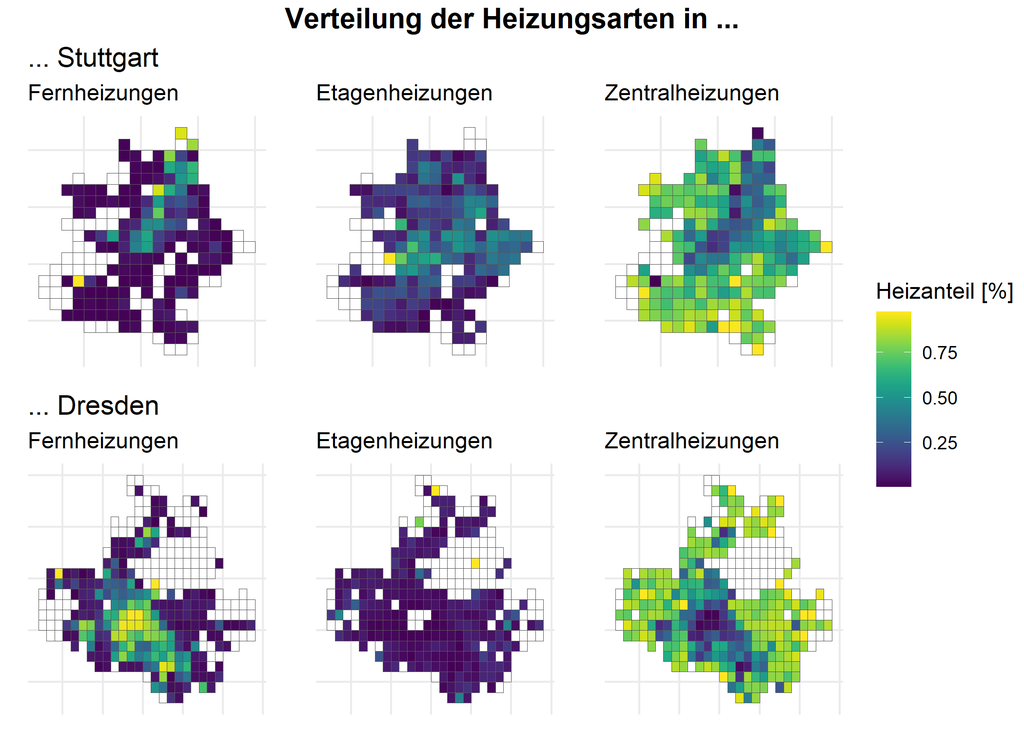

Betrachtet man die Verteilung der verschiedenen Heizungsarten in Stuttgart, so fällt auf, dass in der Innenstadt vor allem Fernwärme und Etagenheizungen genutzt werden. Darüber hinaus ist die Fernwärme im nördlichen Teil Stuttgarts stärker vertreten. In den anderen Stuttgarter Stadtbezirken ist dagegen die Zentralheizung am stärksten vertreten.

Hier zeigt sich beim Vergleich der Durchschnittsmieten in den gleichen Stadtbezirken ein Zusammenhang zwischen höheren Mieten und der Installation von Etagen- oder Fernwärme. So ist z.B. die Stuttgarter Innenstadt gemäß dem Diagramm in Aufgabe 13 eher teurer als andere Stadtteile und diese Stadtteile sind entsprechend mit Fern- und Etagenheizung ausgestattet.

In Dresden ist die Situation etwas anders. Hier gibt es viele Fernwärmeanschlüsse in der Innenstadt und im Süden der Stadt. Etagenheizungen gibt es in Dresden dagegen nur in wenigen Stadtteilen. Den Großteil der Heizungen machen die Zentralheizungen aus. Diese sind vor allem am Stadtrand vertreten, wobei am südlichen Stadtrand eine recht ausgewogene Verteilung von Fern- und Zentralheizung vorliegt.

In Dresden lässt sich kein Zusammenhang zwischen den Mietpreisen in den Stadtbezirken und der Heizungsart feststellen. Grundsätzlich sind die Mieten recht gleichmäßig verteilt, wie die Grafik in Aufgabe 13 zeigt. Die Heizungsarten variieren jedoch bei gleichem Preis sehr stark, so dass hier kein Zusammenhang besteht.

Im Vergleich zwischen Dresden und Stuttgart fällt auf, dass in der ostdeutschen Stadt kaum Etagenheizungen eingesetzt werden. Sie kommen nur in einzelnen Stadtteilen vor. Dies könnte darauf zurückzuführen sein, dass diese Stadtteile saniert wurden und man sich bei der Wahl der Heizungsart für eine Etagenheizung entschieden hat und diese Stadtteile nicht an die Fernwärmeinfrastruktur angeschlossen sind. Ein Grund für die Dominanz der Fernwärme in einigen Bezirken könnte sein, dass diese wenigen Gebiete im Rahmen einer Sanierung an das Fernwärmenetz angeschlossen wurden. Dadurch sind diese Wohnungen von der Fernwärme abhängig, da es für die Bewohner dieser Wohnungen keine alternative Heizmöglichkeit gibt. Zentralheizungen dominieren wahrscheinlich in Gebieten, die seit längerer Zeit nicht renoviert und daher nicht an das Fernwärmenetz angeschlossen wurden. In neueren Wohnungen und Neubauten am Stadtrand wurden häufig Zentralheizungen installiert, da sie effizienter und kostengünstiger zu betreiben sind und das Fernwärmenetz zu diesem Zeitpunkt noch nicht ausgebaut war. Dies erklärt die Dominanz der Zentralheizung in den Randgebieten von Stuttgart und Dresden, wo neuere Wohnsiedlungen entstanden sind.

Abschließend sollen Sie die Zusatzaufgabe noch einmal rekapitulieren und einige Fragen dazu beantworten.

20. Sie sollen sich noch einmal bewusst werden, was Sie in den vorherigen Aufgaben analysiert haben und in welcher Form ihre Ergebnisse anwendbar und verallgemeinbar sind. Beantworten Sie dazu Frage 1 und 2.

Frage 1: Betrachten Sie hierzu noch einmal exemplarisch die Städte Stuttgart und Dresden.

- Sind die Zusammenhänge zwischen Mietpreisen in den Städten und sozioökonomischer Faktoren vor allem auf Unterschiede zwischen den Städten oder auf Unterschiede innerhalb der Stadt zurückzuführen. Bei welchen Faktoren ist dies der Fall, wo nicht?
- Wie kann der Staat im Hinblick auf die unterschiedlichen Heizungsarten in den Städten eingreifen, um Wohnraum preiswerter zu gestalten?

Frage 2: Schauen Sie sich noch einmal die Verteilung der Heizungsarten (Fern-, Etagen- und Zentralheizungen) für Stuttgart und Dresden in Aufgabe 19 an. Betrachten Sie im Vergleich dazu ihre Grafik aus Aufgabe 8, sowie ihre Tabelle in Aufgabe 13?

- Was fällt Ihnen hier auf?
- Gibt es bestimmte Heizungstypen, die nur in alten oder neuen Wohnungen vorkommen?
- Welche Schlüsse würden Sie ziehen, die mit Handlungen der Politik einhergehen?

Die Mietpreise in Stuttgart und Dresden sind sowohl durch Unterschiede zwischen den Städten als auch durch Unterschiede innerhalb der Städte beeinflusst. In Stuttgart, einer wirtschaftlich starken Stadt mit vielen Unternehmen und guter Infrastruktur, sind die Mietpreise tendenziell höher als in Dresden, das sich erst in den letzten Jahren wirtschaftlich vom Sozialismus der deutschen demokratischen Republik und den anschließenden Turbulenzen durch die Wiedervereinigung Deutschlands erholt hat. Innerhalb der Städte gibt es ebenfalls Unterschiede: In den zentraleren Stadtteilen sind die Mietpreise in der Regel höher als in den Außenbezirken. Die sozioökonomischen Faktoren, die die Mietpreise beeinflussen, wirken in beiden Städten unterschiedlich. In Stuttgart spielt das hohe Einkommensniveau und die hohe Nachfrage nach Wohnraum eine größere Rolle, während in Dresden die historischen Entwicklungen und die Sanierung von Wohnungen nach der Wiedervereinigung eine größere Bedeutung haben. Der Staat kann im Hinblick auf die unterschiedlichen Heizungsarten in den Städten eingreifen, um Wohnraum preiswerter zu gestalten. Eine Möglichkeit wäre die Förderung von energiesparenden Heizungssystemen wie Wärmepumpen oder Solarthermie. Der Staat könnte finanzielle Anreize für Vermieter schaffen, die ihre Gebäude auf energiesparende Heizungssysteme umrüsten. Auch die Einführung von strengeren Energieeffizienzstandards für Neubauten und die Sanierung von Altbauten könnten dazu beitragen, die Heizkosten zu senken und somit die Mietpreise zu stabilisieren. Diese Maßnahme würde sich zusätzlich positiv auf die Umwelt auswirken.